# TALLER 4

### 2.1.6 Actores 11 y 12

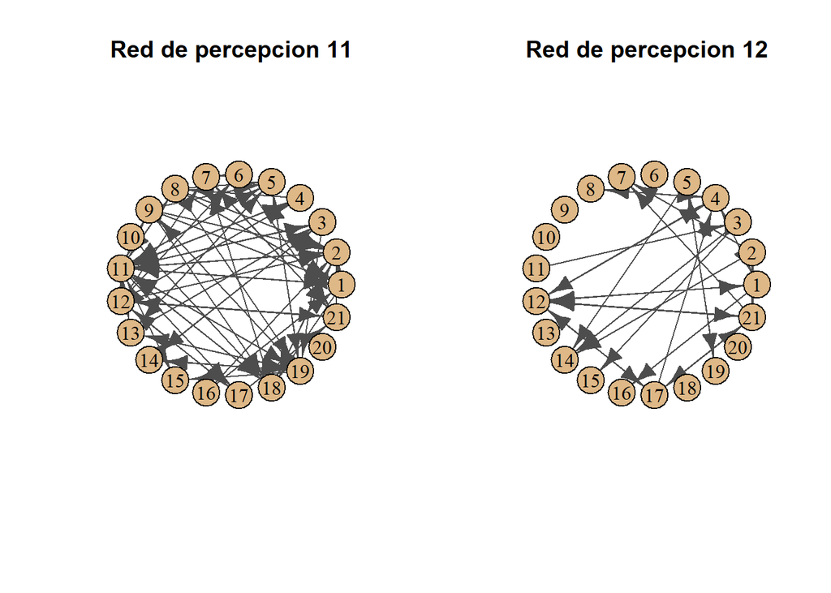

### 2.1.7 Actores 13 y 14

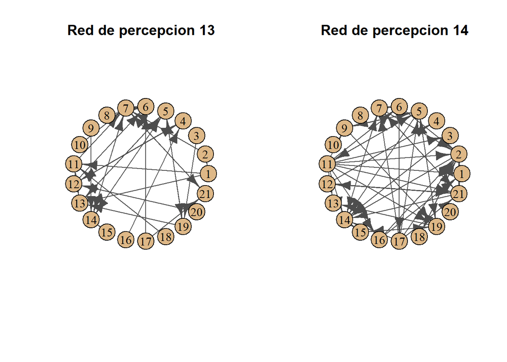

### 2.1.8 Actores 15 y 16

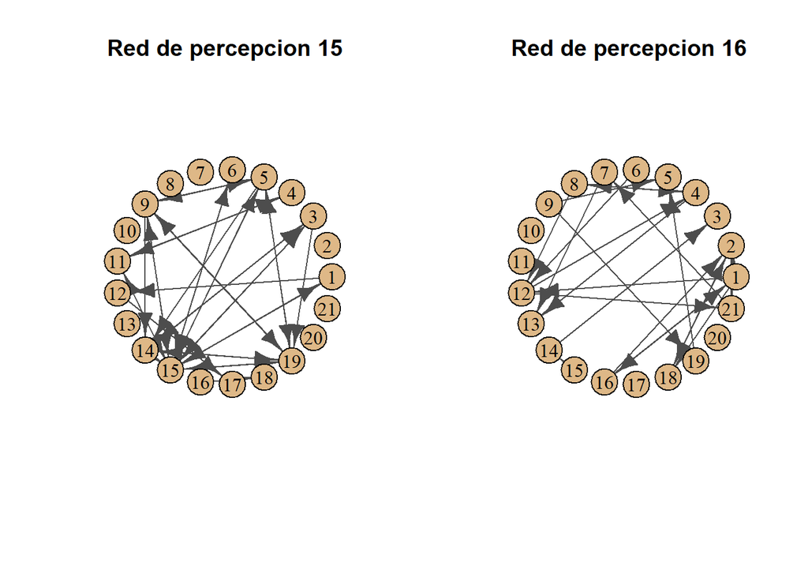

### 2.1.9 Actores 17 y 18

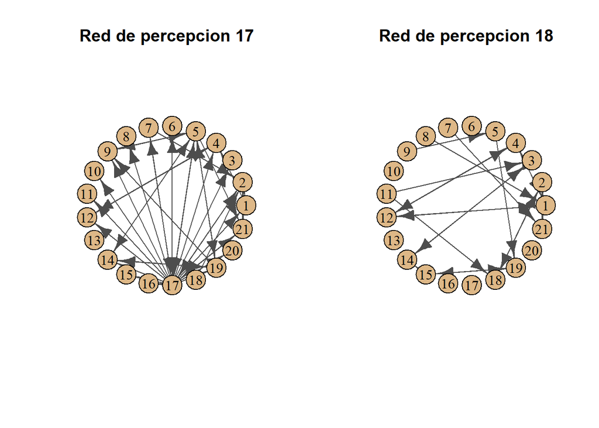

### 2.1.10 Actores 19 y 20

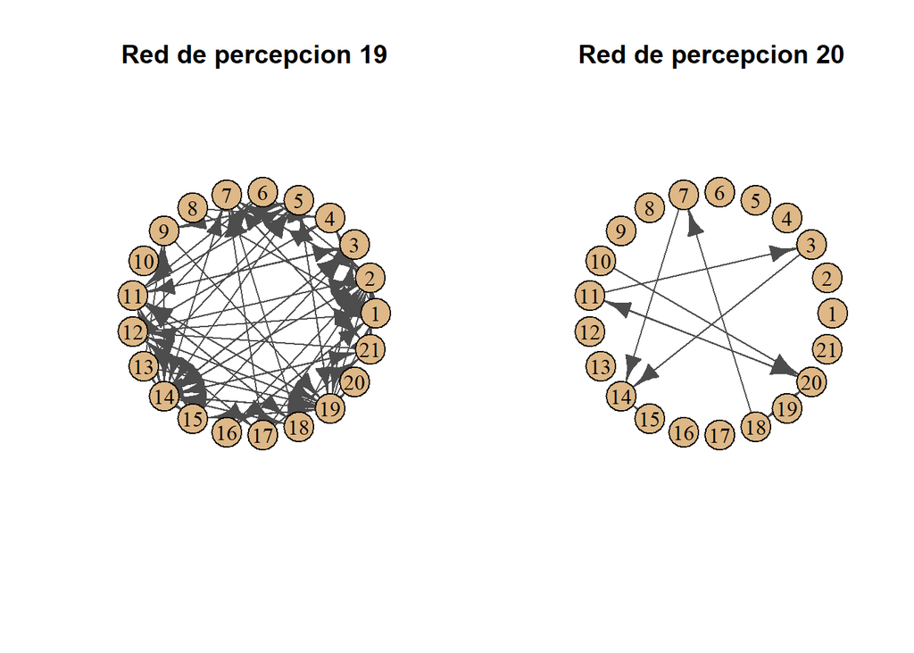

### 2.1.11 Actor 21 y Consenso

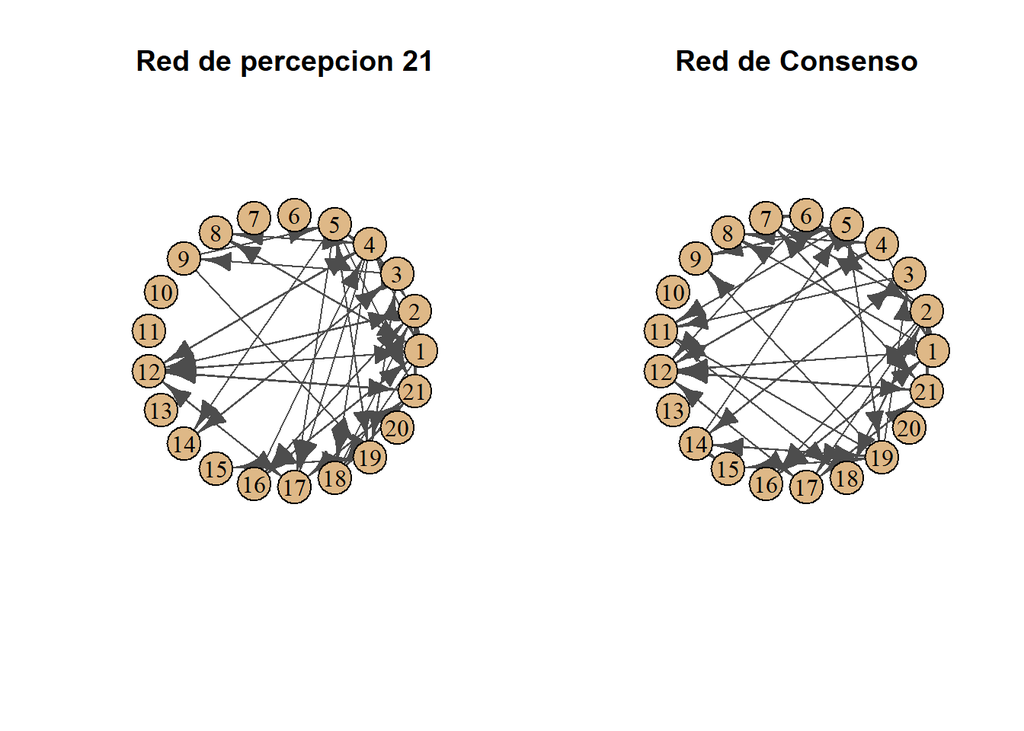

### 2.1.12 Tabla de Jaccard

```r
jaccard_tab %>%
  arrange(desc(jaccard)) %>%
  kableExtra::kbl(caption = "Coeficiente de Jaccard entre los actores y la red de consenso") %>%
  kableExtra::kable_styling(
    full_width = FALSE,
    position = "center"
  ) %>%
  kableExtra::column_spec(8, bold = T) %>%
  kableExtra::row_spec(0, bold = T) %>%
  kableExtra::row_spec(1:3, bold = T, color = "white", background = "#D7261E")
```

Table 2.1: Coeficiente de Jaccard entre los actores y la red de consenso

| actor | ego_out | ego_in | cons_out | cons_in | interseccion | union | jaccard |
| --- | --- | --- | --- | --- | --- | --- | --- |
| 18 | 1 | 2 | 1 | 2 | 3 | 3 | 1.0000000 |
| 12 | 4 | 4 | 4 | 5 | 8 | 9 | 0.8888889 |
| 1 | 5 | 5 | 4 | 4 | 8 | 10 | 0.8000000 |
| 4 | 6 | 3 | 3 | 2 | 5 | 9 | 0.5555556 |
| 21 | 4 | 5 | 4 | 4 | 6 | 11 | 0.5454545 |
| 16 | 2 | 1 | 1 | 2 | 2 | 4 | 0.5000000 |
| 19 | 9 | 7 | 6 | 3 | 8 | 17 | 0.4705882 |
| 2 | 3 | 5 | 7 | 4 | 6 | 13 | 0.4615385 |
| 5 | 7 | 6 | 3 | 3 | 6 | 13 | 0.4615385 |
| 3 | 2 | 1 | 2 | 2 | 2 | 5 | 0.4000000 |
| 8 | 1 | 0 | 1 | 2 | 1 | 3 | 0.3333333 |
| 15 | 8 | 8 | 1 | 2 | 3 | 16 | 0.1875000 |
| 6 | 6 | 4 | 1 | 2 | 2 | 11 | 0.1818182 |
| 7 | 0 | 8 | 3 | 2 | 2 | 11 | 0.1818182 |
| 17 | 18 | 5 | 2 | 3 | 4 | 24 | 0.1666667 |
| 11 | 13 | 12 | 1 | 3 | 4 | 25 | 0.1600000 |
| 14 | 2 | 8 | 4 | 2 | 2 | 14 | 0.1428571 |
| 9 | 0 | 0 | 1 | 2 | 0 | 3 | 0.0000000 |
| 10 | 7 | 8 | 0 | 0 | 0 | 15 | 0.0000000 |
| 13 | 2 | 4 | 0 | 0 | 0 | 6 | 0.0000000 |
| 20 | 2 | 3 | 0 | 0 | 0 | 5 | 0.0000000 |

### 2.1.13 Tabla de sensibilidad

```r
metricas_tab %>%
  arrange(desc(sensibilidad)) %>%
  kableExtra::kbl(caption = "Métrica de sensibilidad de la percepción de los actores y la red de consenso") %>%
  kableExtra::kable_styling(
    full_width = FALSE,
    position = "center"
  ) %>%
  kableExtra::column_spec(c(6,7), bold = T) %>%
  kableExtra::row_spec(c(19,20), bold = T, color = "white", background = "#D7261E")
```

Table 2.2: Métrica de sensibilidad de la percepción de los actores y la red de consenso

| actor | TP | FP | FN | TN | sensibilidad | especificidad | precision | exactitud |
| --- | --- | --- | --- | --- | --- | --- | --- | --- |
| 19 | 33 | 41 | 16 | 351 | 0.6734694 | 0.8954082 | 0.4459459 | 0.8707483 |
| 5 | 30 | 39 | 19 | 353 | 0.6122449 | 0.9005102 | 0.4347826 | 0.8684807 |
| 21 | 30 | 20 | 19 | 372 | 0.6122449 | 0.9489796 | 0.6000000 | 0.9115646 |
| 1 | 28 | 32 | 21 | 360 | 0.5714286 | 0.9183673 | 0.4666667 | 0.8798186 |
| 11 | 28 | 43 | 21 | 349 | 0.5714286 | 0.8903061 | 0.3943662 | 0.8548753 |
| 7 | 27 | 51 | 22 | 341 | 0.5510204 | 0.8698980 | 0.3461538 | 0.8344671 |
| 4 | 26 | 10 | 23 | 382 | 0.5306122 | 0.9744898 | 0.7222222 | 0.9251701 |
| 14 | 22 | 26 | 27 | 366 | 0.4489796 | 0.9336735 | 0.4583333 | 0.8798186 |
| 12 | 21 | 6 | 28 | 386 | 0.4285714 | 0.9846939 | 0.7777778 | 0.9229025 |
| 17 | 19 | 22 | 30 | 370 | 0.3877551 | 0.9438776 | 0.4634146 | 0.8820862 |
| 16 | 18 | 7 | 31 | 385 | 0.3673469 | 0.9821429 | 0.7200000 | 0.9138322 |
| 6 | 17 | 12 | 32 | 380 | 0.3469388 | 0.9693878 | 0.5862069 | 0.9002268 |
| 10 | 17 | 28 | 32 | 364 | 0.3469388 | 0.9285714 | 0.3777778 | 0.8639456 |
| 18 | 17 | 4 | 32 | 388 | 0.3469388 | 0.9897959 | 0.8095238 | 0.9183673 |
| 2 | 16 | 5 | 33 | 387 | 0.3265306 | 0.9872449 | 0.7619048 | 0.9138322 |
| 15 | 14 | 20 | 35 | 372 | 0.2857143 | 0.9489796 | 0.4117647 | 0.8752834 |
| 13 | 11 | 22 | 38 | 370 | 0.2244898 | 0.9438776 | 0.3333333 | 0.8639456 |
| 3 | 6 | 1 | 43 | 391 | 0.1224490 | 0.9974490 | 0.8571429 | 0.9002268 |
| 9 | 6 | 0 | 43 | 392 | 0.1224490 | 1.0000000 | 1.0000000 | 0.9024943 |
| 8 | 5 | 0 | 44 | 392 | 0.1020408 | 1.0000000 | 1.0000000 | 0.9002268 |
| 20 | 1 | 9 | 48 | 383 | 0.0204082 | 0.9770408 | 0.1000000 | 0.8707483 |

## 2.2 Discusión

La comparación entre las percepciones individuales y la red de consenso evidencia una elevada variabilidad en el grado de coincidencia entre actores. Mientras algunos presentan una similitud casi perfecta con el consenso (por ejemplo, **los actores 18, 12 y 1** 2.1), otros muestran escasa o nula correspondencia, lo que refleja diferencias importantes en la forma de percibir la estructura de amistad. En términos de clasificación, se obervó en la tabla 2.2 la elevada especificidad observada en prácticamente todos los actores indica un amplio acuerdo para identificar la ausencia de relaciones. En contraste, la sensibilidad presenta una variabilidad considerable, sugiriendo que existe menor consenso para reconocer las amistades efectivamente presentes. En conjunto, estos resultados indican que la red de consenso captura adecuadamente las relaciones más ampliamente compartidas entre los participantes, aunque simplifica percepciones individuales que difieren sustancialmente del patrón mayoritario.

## 2.3 b. Realice un análisis descriptivo detallado de la red de consenso, destacando sus propiedades estructurales y métricas clave como densidad, transitividad, distribucion de grados, entre otras. Utilice tablas y gráficos según sea necesario para presentar la informacion de manera clara y organizada. Interprete los resultados obtenidos, destacando los patrones relevantes y su implicacion en el contexto del estudio, limitando el análisis a un máximo de 1000 palabras.

El análisis se encuentra en el siguiente numeral denominado **Discusión**.

### 2.3.1 Tabla comparativa

| Red | Densidad | Transitividad.Global | Reciprocidad | Cercanía | Componentes |
| --- | --- | --- | --- | --- | --- |
| Actor 1 | 0.1428571 | 0.4962406 | 0.8000000 | 0.3736726 | 3 |
| Actor 2 | 0.0500000 | 0.1250000 | 0.6666667 | 0.4831634 | 3 |
| Actor 3 | 0.0166667 | 0.6000000 | 0.5714286 | 0.9375000 | 3 |
| Actor 4 | 0.0857143 | 0.4347826 | 0.6111111 | 0.6109797 | 3 |
| Actor 5 | 0.1642857 | 0.4948454 | 0.5797101 | 0.4744985 | 3 |
| Actor 6 | 0.0690476 | 0.3818182 | 0.6206897 | 0.6528993 | 3 |
| Actor 7 | 0.1857143 | 0.5194805 | 0.4358974 | 0.4749194 | 3 |
| Actor 8 | 0.0119048 | 0.0000000 | 0.4000000 | 0.8666667 | 3 |
| Actor 9 | 0.0142857 | NaN | 0.6666667 | 1.0000000 | 3 |
| Actor 10 | 0.1071429 | 0.3750000 | 0.7555556 | 0.4061887 | 3 |
| Actor 11 | 0.1690476 | 0.4415094 | 0.6197183 | 0.4755967 | 3 |
| Actor 12 | 0.0642857 | 0.3428571 | 0.6666667 | 0.6061683 | 3 |
| Actor 13 | 0.0785714 | 0.1090909 | 0.4848485 | 0.3788871 | 3 |
| Actor 14 | 0.1142857 | 0.4308511 | 0.4166667 | 0.3601830 | 3 |
| Actor 15 | 0.0809524 | 0.5909091 | 0.8235294 | 0.5804382 | 3 |
| Actor 16 | 0.0595238 | 0.3243243 | 0.4000000 | 0.5883677 | 3 |
| Actor 17 | 0.0976190 | 0.1989796 | 0.5365854 | 0.6061956 | 3 |
| Actor 18 | 0.0500000 | 0.2142857 | 0.6666667 | 0.7314815 | 3 |
| Actor 19 | 0.1761905 | 0.4720280 | 0.6216216 | 0.4690580 | 3 |
| Actor 20 | 0.0238095 | 0.0000000 | 0.4000000 | 0.7238095 | 3 |
| Actor 21 | 0.1190476 | 0.5338983 | 0.7600000 | 0.5346700 | 3 |
| Red de consenso | 0.1166667 | 0.3900000 | 0.6938776 | 0.4211672 | 3 |

### 2.3.2 Distribución del grado

```r
d <- degree(graph = grafos21[[22]])
```

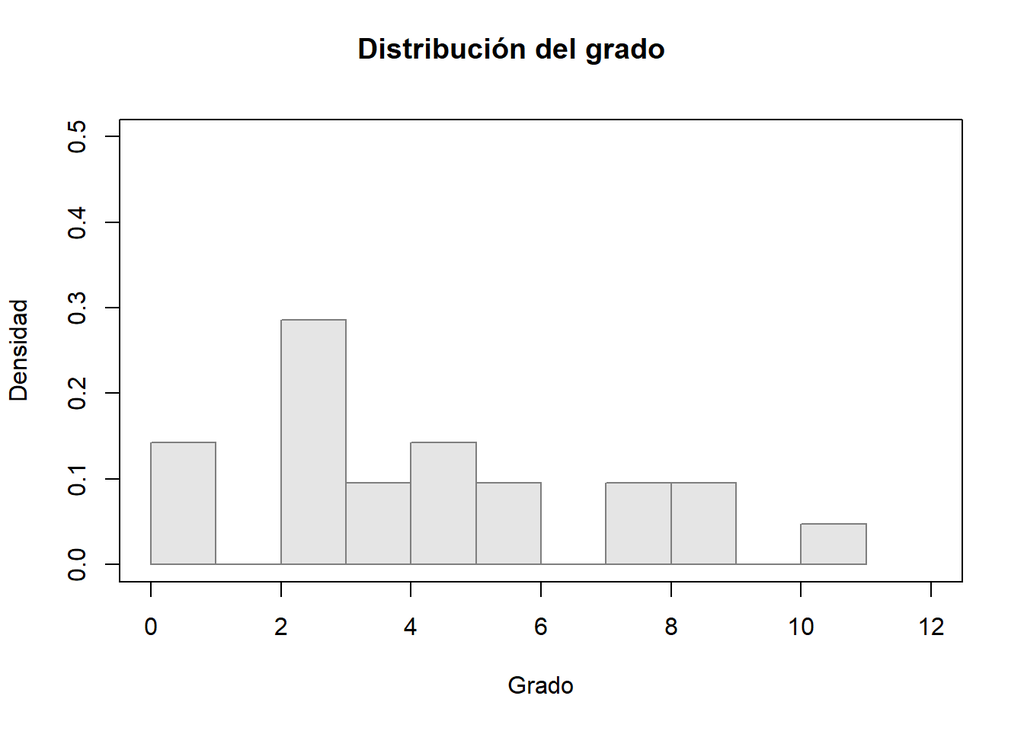

Figure 2.1: Distribución del grado de la red de consenso

```r
# histograma
plot(x = NA,
     y = NA,
     type = "n",
     xlim = c(0,12),
     ylim = c(0,0.5),
     xlab = "Grado",
     ylab = "Densidad",
     main = "")
hist(d, freq = F, col = "gray90", border = "gray50", add = T, breaks=10)
title(main = "Distribución del grado", outer = T, line = -2)
```

## 2.4 Discusión

En términos generales, la red de consenso presenta características que se ubican dentro del rango observado en las percepciones individuales, sin representar los valores extremos de ninguna métrica. Esto indica que el procedimiento de consenso logra sintetizar la información proporcionada por los 21 actores, reteniendo principalmente las relaciones de amistad que cuentan con un respaldo compartido por una proporción importante del grupo.

La densidad moderada refleja que el consenso descarta muchas relaciones percibidas únicamente por unos pocos individuos, mientras que la alta reciprocidad evidencia que las amistades conservadas suelen ser reconocidas de manera mutua. Asimismo, la transitividad global muestra que la red mantiene cierto grado de cohesión local mediante la presencia de tríadas cerradas, aunque en menor medida que las percepciones más optimistas.

Un resultado particularmente relevante es que todas las redes, incluida la de consenso, presentan exactamente tres componentes, lo que sugiere que la fragmentación general del sistema es una característica robusta y consistente entre las distintas percepciones. En otras palabras, aunque los actores difieren en el número de amistades que reconocen, existe un acuerdo considerable respecto a la estructura global de conectividad de la red.

## 2.5 c. Calcule el grado normalizado para cada actor en todas las percepciones individuales y en la red de consenso. Construya diagramas de caja para cada actor, mostrando la distribucion de su grado a través de las percepciones y el consenso. Distinga el grado basado en la percepcion propia de cada actor con un triángulo rojo ($\triangle$) y el grado basado en la red de consenso con una cruz azul ($\times$). Incluya todos los diagramas de caja en un único gráfico. Un ejemplo de este tipo de gráfico puede encontrarse en este enlace, página 9. Analice si los actores tienen una percepcion adecuada de su rol dentro del sistema social y limite la interpretacion de los resultados a un máximo de 1000 palabras.

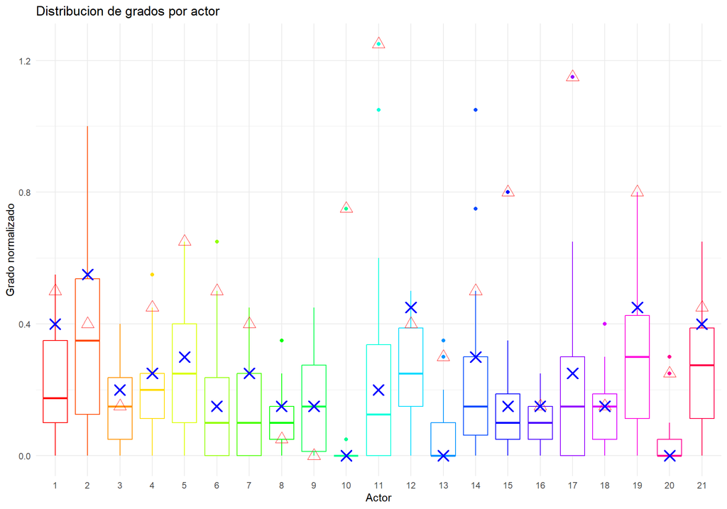

## 2.6 d. Ajuste un modelo de grafos aleatorio exponencial a la red de consenso, utilizando como términos en el predictor lineal el número de aristas y las covariables con efectos homofílicos. Realice una interpretacion detallada de los resultados obtenidos, identificando el impacto de las covariables en la estructura de la red y discutiendo la adecuacion del modelo en este contexto. Limite la interpretacion a un máximo de 1000 palabras.

```r
krackhardt21c <- read_table("krackhardt21c.txt")
V(grafos21[[22]])$edad <- krackhardt21c$age
V(grafos21[[22]])$tenencia <- krackhardt21c$tenure
V(grafos21[[22]])$nivel <- krackhardt21c$level
V(grafos21[[22]])$departamento <- krackhardt21c$dept
red_consenso <- asNetwork(grafos21[[22]])
ergmconsenso <- ergm(red_consenso ~
        edges +
        nodematch("nivel") +
        nodematch("departamento") +
        absdiff("edad") +
        absdiff("tenencia")
    )
```

```
## Starting maximum pseudolikelihood estimation (MPLE):
```

```
## Obtaining the responsible dyads.
```

```
## Evaluating the predictor and response matrix.
```

```
## Maximizing the pseudolikelihood.
```

```
## Finished MPLE.
```

```
## Evaluating log-likelihood at the estimate.
```

```r
tabla_ergm <- summary(ergmconsenso)$coefficients  %>%
  as.data.frame() %>%
  tibble::rownames_to_column("Parámetro") %>%
  rename(
    "Estimación" = Estimate,
    `Error estándar` = `Std. Error`,
    `Valor z` = `z value`,
    `Valor p` = `Pr(>|z|)`
  ) %>%
  mutate(
    `Valor p` = ifelse(`Valor p` < 0.001,
                       "<0.001",
                       sprintf("%.3f", `Valor p`)),
    across(c(Estimación, `Error estándar`, `Valor z`),
           ~ round(.x, 3))
  )
```

```r
tabla_ergm %>%
  kableExtra::kbl(
    caption = "Resultados del modelo ERGM para la red de consenso",
    align = c("l", "c", "c", "c", "c"),
    booktabs = TRUE
  ) %>%
  kableExtra::kable_styling(
    full_width = FALSE,
    bootstrap_options = c("striped", "hover")
  ) %>%
  kableExtra::row_spec(
    c(2,3,4,5),
    color = "#7f8c8d",
    italic = TRUE
  ) %>%
  kableExtra::row_spec(
    c(1,3),
    bold = TRUE,
    background = "#CF2F40",
    color = "white"
  )
```

Table 2.3: Resultados del modelo ERGM para la red de consenso

| Parámetro | Estimación | Error estándar | MCMC % | Valor z | Valor p |
| --- | --- | --- | --- | --- | --- |
| edges | -2.085 | 0.365 | 0 | -5.705 | <0.001 |
| nodematch.nivel | -0.301 | 0.330 | 0 | -0.912 | 0.362 |
| nodematch.departamento | 1.811 | 0.326 | 0 | 5.557 | <0.001 |
| absdiff.edad | -0.023 | 0.023 | 0 | -0.998 | 0.318 |
| absdiff.tenencia | -0.025 | 0.029 | 0 | -0.860 | 0.390 |

El modelo ERGM muestra que la pertenencia al mismo departamento constituye el único atributo nodal asociado significativamente con la formación de vínculos de consenso (β=1.811, p<0.001). Esto indica que, controlando por las demás variables del modelo, los actores pertenecientes al mismo departamento presentan una mayor propensión a establecer relaciones de consenso que aquellos de departamentos diferentes. En contraste, el nivel, la diferencia de edad y la diferencia en la tenencia no muestran evidencia de influir en la probabilidad de formación de enlaces.

## 2.7 e. Considere los siguientes modelos (sin covariables) para ajustarlos a la red de consenso:

1. $M1$: Modelo de grafos aleatorios.
2. $M2$: Modelo de grafos aleatorios generalizado.
3. $M3$: Modelo de grafos aleatorio exponencial con número de aristas y triángulos.
4. $M4$: Modelo de bloques estocásticos.
5. $M5$: Modelo latente de distancia clásico con dos dimensiones latentes.
6. $M6$: Modelo de sociabilidad.

Ajuste cada uno de estos modelos y utilice tablas y visualizaciones según sea necesario para mostrar los resultados. Interprete detalladamente los hallazgos de cada modelo, sin límite de palabras para esta seccion, destacando las fortalezas y limitaciones de cada enfoque.

### 2.7.1 Modelo de grafos aleatorios

```r
tabla_ergm <- summary(m1)$coefficients  %>%
  as.data.frame() %>%
  tibble::rownames_to_column("Parámetro") %>%
  rename(
    "Estimación" = Estimate,
    `Error estándar` = `Std. Error`,
    `Valor z` = `z value`,
    `Valor p` = `Pr(>|z|)`
  ) %>%
  mutate(
    `Valor p` = ifelse(`Valor p` < 0.001,
                       "<0.001",
                       sprintf("%.3f", `Valor p`)),
    across(c(Estimación, `Error estándar`, `Valor z`),
           ~ round(.x, 3))
  )
```

```r
tabla_ergm %>%
  kableExtra::kbl(
    caption = "Resultados del modelo ERGM para la red de consenso",
    align = c("l", "c", "c", "c", "c"),
    booktabs = TRUE
  ) %>%
  kableExtra::kable_styling(
    full_width = FALSE,
    bootstrap_options = c("striped", "hover")
  )
```

Table 2.4: Resultados del modelo ERGM para la red de consenso

| Parámetro | Estimación | Error estándar | MCMC % | Valor z | Valor p |
| --- | --- | --- | --- | --- | --- |
| edges | -2.024 | 0.152 | 0 | -13.319 | <0.001 |

El modelo nulo indica que la red presenta una baja propensión general a la formación de enlaces, como lo evidencia el coeficiente negativo y estadísticamente significativo del término edges. Esto refleja que, en ausencia de otros efectos, la red es relativamente dispersa y la probabilidad de que exista un vínculo entre dos actores es baja.

### 2.7.2 Modelo de grafos aleatorios generalizado

#### 2.7.2.1 Tabla

```r
tabla_m2 <- data.frame(Medida=c("Nodos",
                                 "Aristas",
                                 "Grado medio",
                                 "Densidad"),
                        Observada=c(vcount(grafos21[[22]]),
                                    ecount(grafos21[[22]]),
                                    mean(degree(grafos21[[22]])),
                                    edge_density(grafos21[[22]])),
                        Simulada=c(vcount(m2),
                                    ecount(m2),
                                    mean(degree(m2)),
                                    edge_density(m2)))
```

```r
tabla_m2 %>%
  kableExtra::kbl(
    caption = "Resultados del modelo de grafos aleatorios generalizado para la red de consenso",
    align = c("l", "c", "c", "c", "c"),
    booktabs = TRUE,
    digits = 3
  ) %>%
  kableExtra::kable_styling(
    full_width = FALSE,
    bootstrap_options = c("striped", "hover")
  )
```

Table 2.5: Resultados del modelo de grafos aleatorios generalizado para la red de consenso

| Medida | Observada | Simulada |
| --- | --- | --- |
| Nodos | 21.000 | 21.000 |
| Aristas | 49.000 | 49.000 |
| Grado medio | 4.667 | 4.667 |
| Densidad | 0.117 | 0.117 |

#### 2.7.2.2 Visualización

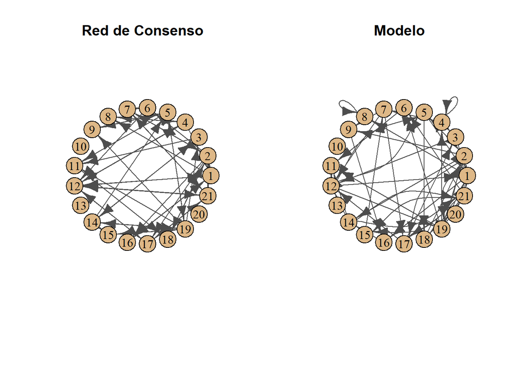

```r
par(mfrow=c(1,2))
plot(grafos21[[22]],
       layout=circle,
       vertex.size = 25,
       vertex.label.color = "black",
       vertex.color       = "burlywood",
       vertex.frame.color = "black",
       edge.color         = "gray30",
       main='Red de Consenso')
plot(m2,
       layout=circle,
       vertex.size = 25,
       vertex.label.color = "black",
       vertex.color       = "burlywood",
       vertex.frame.color = "black",
       edge.color         = "gray30",
       main='Modelo')
```

#### 2.7.2.3 Discusión

El modelo de configuración preserva la secuencia de grados, pero puede generar lazos y aristas múltiples. En consecuencia, aunque reproduce exactamente medidas como el número de aristas y la densidad, la estructura de la red simulada puede diferir de la observada.

### 2.7.3 Modelo de grafos aleatorios exponencial con número de aristas y triángulos

```r
tabla_ergm <- summary(m3)$coefficients  %>%
  as.data.frame() %>%
  tibble::rownames_to_column("Parámetro") %>%
  rename(
    "Estimación" = Estimate,
    `Error estándar` = `Std. Error`,
    `Valor z` = `z value`,
    `Valor p` = `Pr(>|z|)`
  ) %>%
  mutate(
    `Valor p` = ifelse(`Valor p` < 0.001,
                       "<0.001",
                       sprintf("%.3f", `Valor p`)),
    across(c(Estimación, `Error estándar`, `Valor z`),
           ~ round(.x, 3))
  )
```

```r
tabla_ergm %>%
  kableExtra::kbl(
    caption = "Resultados del modelo ERGM con número de aristas y triángulos para la red de consenso",
    align = c("l", "c", "c", "c", "c"),
    booktabs = TRUE
  ) %>%
  kableExtra::kable_styling(
    full_width = FALSE,
    bootstrap_options = c("striped", "hover")
  )
```

Table 2.6: Resultados del modelo ERGM con número de aristas y triángulos para la red de consenso

| Parámetro | Estimación | Error estándar | MCMC % | Valor z | Valor p |
| --- | --- | --- | --- | --- | --- |
| edges | -2.521 | 0.291 | 0 | -8.657 | <0.001 |
| triangle | 1.151 | 0.233 | 0 | 4.931 | <0.001 |

El coeficiente negativo y significativo del término edges indica que la red presenta una baja propensión general a la formación de enlaces, lo que es consistente con una estructura relativamente dispersa. Sin embargo, el coeficiente positivo y significativo del término triangle evidencia una tendencia al cierre triádico, indicando que, cuando dos actores comparten un vecino en común, aumenta la probabilidad de que también establezcan un vínculo entre sí. En consecuencia, aunque la red no es densa, los enlaces existentes muestran una tendencia a organizarse en triángulos.

### 2.7.4 Modelo de bloques estocásticos

#### 2.7.4.1 Tabla

```r
extraer_sbm(modelo = m4) %>%
  dplyr::select(-PL) %>%
  kableExtra::kbl(
    caption = "Resultados del modelo de bloques estocásticos para la red de consenso",
    align = c("l", "c", "c", "c", "c"),
    booktabs = TRUE
  ) %>%
  kableExtra::kable_styling(
    full_width = FALSE,
    bootstrap_options = c("striped", "hover")
  )
```

Table 2.7: Resultados del modelo de bloques estocásticos para la red de consenso

| k_optimo | tamaños | ICL |
| --- | --- | --- |
| 2 | 10, 11 | -145.4828 |

#### 2.7.4.2 Visualización

```r
which.max(m4$ICL)
```

```
## [1] 2
```

```r
Z <- m4$memberships[[2]]$Z

bloques <- apply(
  Z,
  1,
  which.max
)
network::set.vertex.attribute(
  red_nd,
  "bloque",
  bloques
)
```

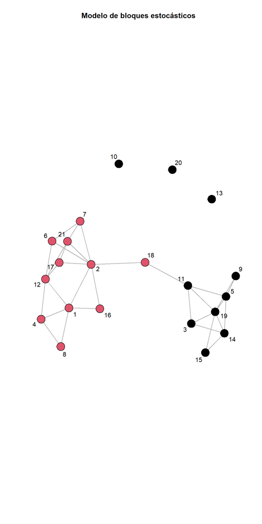

```r
plot(
  red_nd,
  vertex.col = bloques,
  vertex.cex = 2,
  displaylabels = TRUE,
  label = network.vertex.names(red_nd),
  edge.col = "grey70",
  main = "Modelo de bloques estocásticos"
)
```

### 2.7.5 Modelo latente de distancia clásico con dos dimensiones latentes

#### 2.7.5.1 Tabla

```r
tabla_latente <- tibble(
  Característica = c(
    "Modelo",
    "Distribución",
    "Dimensiones latentes",
    "Tamaño de la muestra MCMC",
    "Burn-in",
    "Separación entre muestras"
  ),
  Valor = c(
    "Distancia euclidiana",
    "Bernoulli",
    2,
    m5$control$sample.size,
    m5$control$burnin,
    m5$control$interval
  )
)
```

```r
tabla_latente  %>%
  kbl(
    caption = "Resumen del modelo latente de distancia para la red de consenso",
    align = c("l", "c"),
    booktabs = TRUE
  )  %>%
  kable_styling(
    full_width = FALSE,
    bootstrap_options = c("striped", "hover")
  )
```

Table 2.8: Resumen del modelo latente de distancia para la red de consenso

| Característica | Valor |
| --- | --- |
| Modelo | Distancia euclidiana |
| Distribución | Bernoulli |
| Dimensiones latentes | 2 |
| Tamaño de la muestra MCMC | 4000 |
| Burn-in | 10000 |
| Separación entre muestras | 10 |

#### 2.7.5.2 Visualización

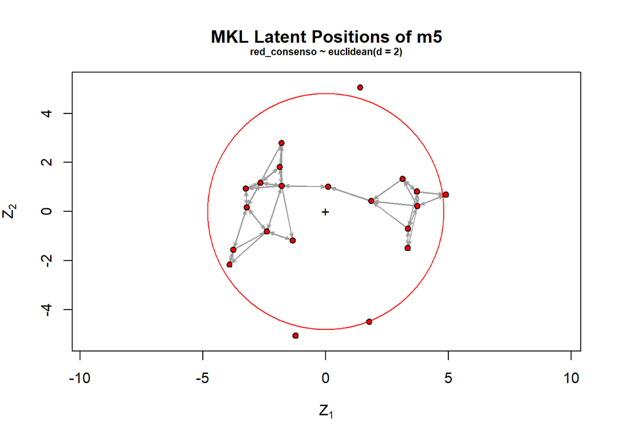

```r
plot(m5)
```

#### 2.7.5.3 Discusión

En conjunto, el modelo latente de distancia evidencia que la proximidad en un espacio bidimensional permite representar adecuadamente la estructura de la red. Además, la presencia de dos agrupaciones principales es consistente con la partición obtenida mediante el modelo de bloques estocásticos, lo que sugiere que ambas metodologías capturan una organización similar de la red desde enfoques distintos: el SBM mediante comunidades discretas y el modelo latente mediante proximidad en un espacio continuo.

### 2.7.6 Modelo de sociabilidad

```r
tabla_sociabilidad <- tibble(

  Parámetro = c(
    "μ",
    "σ²",
    "τ²"
  ),

  `Media posterior` = c(
    mean(m6$mu),
    mean(m6$sigma2),
    mean(m6$tau2)
  ),

  `Desv. estándar` = c(
    sd(m6$mu),
    sd(m6$sigma2),
    sd(m6$tau2)
  ),

  `IC 2.5%` = c(
    quantile(m6$mu, .025),
    quantile(m6$sigma2, .025),
    quantile(m6$tau2, .025)
  ),

  `IC 97.5%` = c(
    quantile(m6$mu, .975),
    quantile(m6$sigma2, .975),
    quantile(m6$tau2, .975)
  )

)  %>%

  mutate(
    across(
      -Parámetro,
      ~ round(.x, 3)
    )
  )
```

```r
tabla_sociabilidad  %>%

  kbl(
    caption = "Resumen posterior del modelo de sociabilidad",
    align = c("l", "c", "c", "c", "c"),
    booktabs = TRUE
  )  %>%

  kable_styling(
    full_width = FALSE,
    bootstrap_options = c(
      "striped",
      "hover"
    )
  )
```

Table 2.9: Resumen posterior del modelo de sociabilidad

| Parámetro | Media posterior | Desv. estándar | IC 2.5% | IC 97.5% |
| --- | --- | --- | --- | --- |
| μ | -1.172 | 0.164 | -1.513 | -0.861 |
| σ² | 1.102 | 1.136 | 0.240 | 3.953 |
| τ² | 0.078 | 0.094 | 0.006 | 0.335 |

## 2.8 Resumen

Resumen modelos ajustados

| Modelo | Parámetros | Qué modela | Resultado principal |
| --- | --- | --- | --- |
| **M1:**Modelo de grafos aleatorios | edges | Densidad | Hay poca densidad |
| **M2:**Modelo de grafos aleatorios generalizado | grado fijo | Secuencia de grados | El modelo preserva las características globales pero no replica la red exactamente igual. |
| **M3:**Modelo de grafos aleatorios exponencial con número de aristas y triángulos | edges + triangle | Cierre triádico | Red poco densa, pero de las aristas que hay hay alta probabilidad de un cierre triádico |
| **M4:**Modelo de bloques estocásticos | SBM | Comunidades | Hay dos comunidades principales de tamaño similar |
| **M5:**Modelo latente de distancia clásico con dos dimensiones latentes | Latente | Distancias ocultas | Dos concentraciones principales de nodos similares a la estructura de bloques estocásticos |
| **M6:**Modelo de sociabilidad | Sociabilidad | Heterogeneidad nodal | Baja propensión a la formación de enlaces y existencia de heterogenidad entre los actores |

## 2.9 f. Evalúe la bondad de ajuste de los modelos ajustados en el numeral anterior utilizando como estadísticos de prueba la densidad, la transitividad, la asortatividad y la distancia geodésica promedio. Presente los resultados en tablas y gráficos, interpretando detalladamente los hallazgos, identificando qué modelos capturan mejor las propiedades observadas en la red de consenso y limitando el análisis a un máximo de 1000 palabras.

```r
estadisticas_red <- function(red){

  if (inherits(red, "network")) {
    red <- intergraph::asIgraph(red)
  }

  tibble(
    densidad = edge_density(red),
    transitividad = transitivity(red, type = "global"),
    asortatividad = assortativity_degree(red),
    geodesica = mean_distance(red, directed = TRUE)
  )

}
obs <- estadisticas_red(grafos21[[22]])
set.seed(2252)
sim_m1 <- simulate(m1, nsim = 100)
res_m1 <- purrr::map_dfr(
  sim_m1,
  estadisticas_red
)  %>%
  dplyr::mutate(modelo = "M1")
sim_m2 <- replicate(
  100,
  sample_degseq(
    degree(red_nda),
    method = "configuration"
  ),
  simplify = FALSE
)
res_m2 <- purrr::map_dfr(
  sim_m2,
  estadisticas_red
)  %>%
  mutate(modelo = "M2")
sim_m3 <- simulate(m3, nsim = 100)
res_m3 <- purrr::map_dfr(
  sim_m3,
  estadisticas_red
) %>%
  mutate(modelo="M3")

P <- m4$prediction(2)
diag(P) <- 0
simular_sbm <- function(P){

  A <- matrix(
    rbinom(
      length(P),
      size = 1,
      prob = as.vector(P)
    ),
    nrow = nrow(P),
    byrow = FALSE
  )

  diag(A) <- 0

  ## Asegurar simetría
  A[lower.tri(A)] <- t(A)[lower.tri(A)]

  graph_from_adjacency_matrix(
    A,
    mode = "undirected",
    diag = FALSE
  )

}
sim_m4 <- replicate(
  100,
  simular_sbm(P),
  simplify = FALSE
)
res_m4 <- purrr::map_dfr(
  sim_m4,
  estadisticas_red
)  %>%
  mutate(
    modelo = "M4"
  )

sim_m5 <- replicate(
  100,
  simulate(m5),
  simplify = FALSE
)
res_m5 <- purrr::map_dfr(
  sim_m5,
  estadisticas_red
)  %>%
  mutate(modelo="M5")

simular_sociabilidad <- function(mu, delta){

  n <- length(delta)

  A <- matrix(0, n, n)

  for(i in 1:(n-1)){

    for(j in (i+1):n){

      p <- pnorm(
        mu +
        delta[i] +
        delta[j]
      )

      A[i,j] <- rbinom(
        1,
        size = 1,
        prob = p
      )

      A[j,i] <- A[i,j]

    }

  }

  graph_from_adjacency_matrix(
    A,
    mode = "undirected",
    diag = FALSE
  )

}

idx <- sample(
  seq_along(m6$mu),
  100
)

sim_m6 <- purrr::map(
  idx,
  \(k){

    simular_sociabilidad(
      mu = m6$mu[k],
      delta = m6$delta[k, ]
    )

  }
)
res_m6 <- purrr::map_dfr(
  sim_m6,
  estadisticas_red
)  %>%
  mutate(
    modelo = "M6"
  )

todos <- bind_rows(
  res_m1,
  res_m2,
  res_m3,
  res_m4,
  res_m5,
  res_m6
)
```

### 2.9.1 Densidad

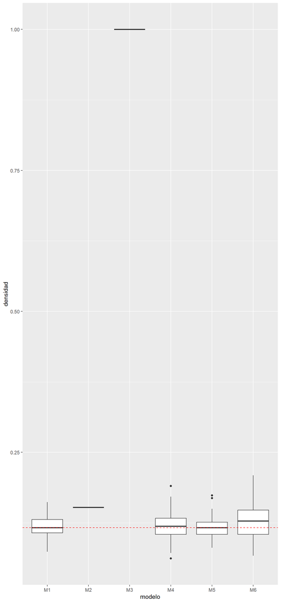

```r
ggplot(
  todos,
  aes(
    x = modelo,
    y = densidad
  )
)+
geom_boxplot()+
geom_hline(
  yintercept = obs$densidad,
  colour="red",
  linetype=2
)
```

### 2.9.2 Transitividad

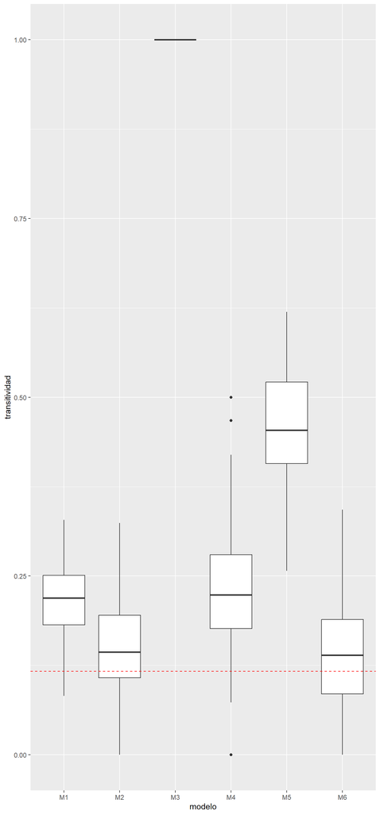

```r
ggplot(
  todos,
  aes(
    x = modelo,
    y = transitividad
  )
)+
geom_boxplot()+
geom_hline(
  yintercept = obs$densidad,
  colour="red",
  linetype=2
)
```

### 2.9.3 Asortatividad

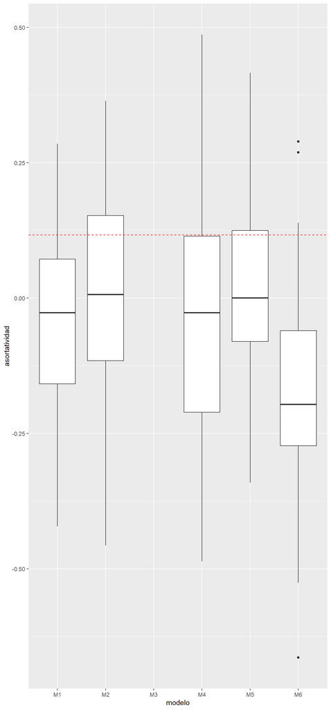

```r
ggplot(
  todos,
  aes(
    x = modelo,
    y = asortatividad
  )
)+
geom_boxplot()+
geom_hline(
  yintercept = obs$densidad,
  colour="red",
  linetype=2
)
```

### 2.9.4 Distancia geodésica

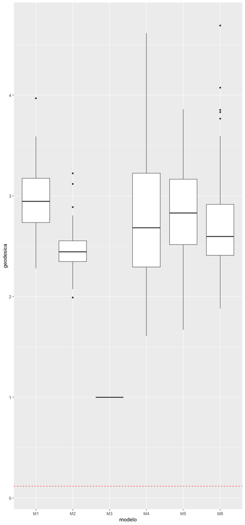

```r
ggplot(
  todos,
  aes(
    x = modelo,
    y = geodesica
  )
)+
geom_boxplot()+
geom_hline(
  yintercept = obs$densidad,
  colour="red",
  linetype=2
)
```

## 2.10 g. Compruebe la capacidad predictiva de los modelos ajustados en el numeral anterior mediante validacion cruzada con cinco (5 folds). Evalúe el rendimiento predictivo de cada modelo, utilizando tablas y gráficos para resumir los resultados. Interprete los hallazgos, destacando cuál modelo proporciona las mejores predicciones y por qué, limitando la interpretacion a un máximo de 1000 palabras.

### 2.10.1 Tabla de resumen

```r
cv_total <- bind_rows(
  cv_m1 %>%  mutate(Modelo = "M1: Bernoulli"),
  cv_m2 %>%  mutate(Modelo = "M2: Grados"),
  cv_m3 %>%  mutate(Modelo = "M3: ERGM"),
  cv_m4 %>%  mutate(Modelo = "M4: SBM"),
  cv_m5 %>%  mutate(Modelo = "M5: Latente"),
  cv_m6 %>%  mutate(Modelo = "M6: Sociabilidad")
)

tabla_cv <-
  cv_total %>%
  group_by(Modelo) %>%
  summarise(
    AUC_media = mean(AUC),
    AUC_sd = sd(AUC),
    Accuracy_media = mean(Accuracy),
    Accuracy_sd = sd(Accuracy),
    .groups = "drop"
  ) %>%
  mutate(
    across(
      -Modelo,
      ~round(.x, 3)
    )
  )
```

```r
tabla_cv %>%
  kableExtra::kbl(caption = "Resultados de la validación cruzada de cinco folds",
    booktabs = TRUE,
    align = c("l","c","c","c","c"),
    col.names = c(
      "Modelo",
      "AUC media",
      "DE",
      "Accuracy media",
      "DE"
    )) %>%
  kableExtra::kable_styling(
    full_width = FALSE,
    position = "center"
  ) %>%
  kableExtra::row_spec(0, bold = T) %>%
  kableExtra::row_spec(
    c(5),
    bold = TRUE,
    background = "#CF2F40",
    color = "white"
  )
```

Table 2.10: Resultados de la validación cruzada de cinco folds

| Modelo | AUC media | DE | Accuracy media | DE |
| --- | --- | --- | --- | --- |
| M1: Bernoulli | 0.500 | 0.000 | 0.876 | 0.052 |
| M2: Grados | 0.798 | 0.062 | 0.843 | 0.072 |
| M3: ERGM | 0.715 | 0.133 | 0.876 | 0.052 |
| M4: SBM | 0.769 | 0.049 | 0.876 | 0.052 |
| M5: Latente | 0.926 | 0.080 | 0.876 | 0.062 |
| M6: Sociabilidad | 0.573 | 0.086 | 0.876 | 0.052 |

### 2.10.2 Boxplot del AUC

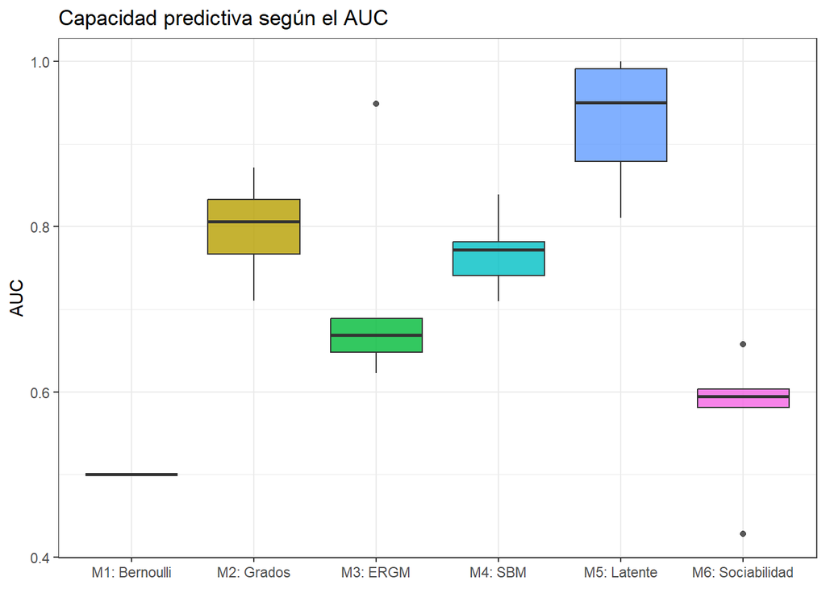

Figure 2.2: Boxplot del área bajo la curva (AUC por sus siglas en inglés)

```r
ggplot(
  cv_total,
  aes(
    Modelo,
    AUC,
    fill = Modelo
  )
) +
  geom_boxplot(
    alpha = .8
  ) +
  labs(
    x = NULL,
    y = "AUC",
    title = "Capacidad predictiva según el AUC"
  ) +
  theme_bw() +
  theme(
    legend.position = "none"
  )
```

### 2.10.3 Discusión

# 3 Mafia

El objetivo de este taller es analizar la estructura de una red social derivada de la orden de detencion preventiva emitida por el Tribunal de Messina en marzo de 2007, en el marco de la operacion anti mafia “Montagna”. La investigacion se centro en la familia “Mistretta” y el clan “Batanesi”, que infiltraron diversas actividades economicas entre 2003 y 2007. Los datos se encuentran en el archivo *mafia.RData*. La red representa individuos y relaciones asociadas con actividades ilícitas, donde los nodos corresponden a personas o entidades y los arcos a relaciones de influencia o interaccion. La red es dirigida y ponderada.

## 3.1 a. Explorar la estructura de los datos de nodos y aristas, identificar la informacion relevante para el análisis, verificar si la red es simple y ponderada, construir la red, calcular su orden y tamaño, generar una visualizacion inicial e identificar los nodos más conectados.

### 3.1.1 Resumen

```r
load("C:/PERSONAL_MAPU/UNIVERSIDADES/NACIONAL/ANALISIS_ESTADISTICO_DE_REDES/TALLER_3/REDES_TALLER_2/TALLER_4/mafia.rdata")


names(datos) <- c("from", "to", "weight")
g <- graph_from_data_frame(
  d = datos,
  directed = TRUE
)

# table(E(G)$weight) G es no dirigida, pero el enunciado dice lo opuesto
# table(E(g)$weight) son iguales entonces copiare el role de G a g
# all.equal(
#     as_adjacency_matrix(
#        as_undirected(g),
#        attr = "weight"
#    ),
#    as_adjacency_matrix(
#        G,
#        attr = "weight"
#    )
#)
# [1] TRUE  -> son iguales

V(g)$role <- V(G)$role

V(g)$clan <- str_extract(
  V(g)$role,
  "(?<=family '').*?(?='')"
)

V(g)$clan[is.na(V(g)$clan)] <- "Sin clan"

resumen <- data.frame(
  Propiedad = c(
    "Red simple",
    "Red ponderada",
    "Red dirigida",
    "Orden",
    "Tamaño"
  ),
  Valor = c(
    is_simple(g),
    is_weighted(g),
    is_directed(g),
    vcount(g),
    ecount(g)
  )
)
```

Table 3.1: Resumen

| Propiedad | Valor |
| --- | --- |
| Red simple | 1 |
| Red ponderada | 1 |
| Red dirigida | 1 |
| Orden | 143 |
| Tamaño | 325 |

### 3.1.2 Visualización

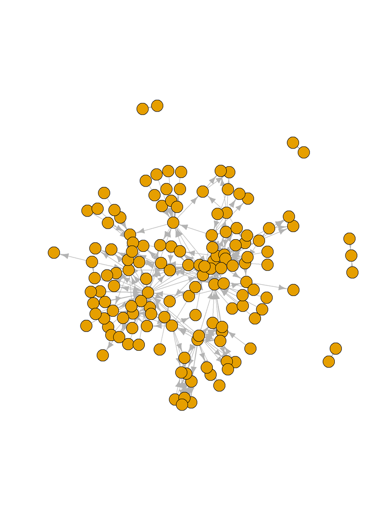

```r
set.seed(2105)

plot(
  g,
  vertex.size = 8,
  vertex.label = NA,
  edge.color = "gray70"
)
```

### 3.1.3 Nodos más conectados

```r
grado <- degree(g)
top10 <- data.frame(
  nodo = names(grado),
  grado = grado
)

top10 <- top10  %>%
  dplyr::arrange(desc(grado))  %>%
  dplyr::slice(1:10)
row.names(top10) <- NULL
```

Table 3.2: Top 10 nodos con mayor grado

| nodo | grado |
| --- | --- |
| N18 | 40 |
| N47 | 26 |
| N68 | 25 |
| N27 | 19 |
| N61 | 18 |
| N22 | 17 |
| N12 | 16 |
| N29 | 16 |
| N11 | 15 |
| N45 | 14 |

## 3.2 b. Analizar la estructura global de la red mediante el grado nodal, la conectividad, los componentes, el diámetro y las distancias geodésicas, complementando el estudio con una visualizacion en la que los nodos se distingan por clan y tamaño según su grado.

### 3.2.1 Distribución del grado

```r
d <- degree(graph = g)
```

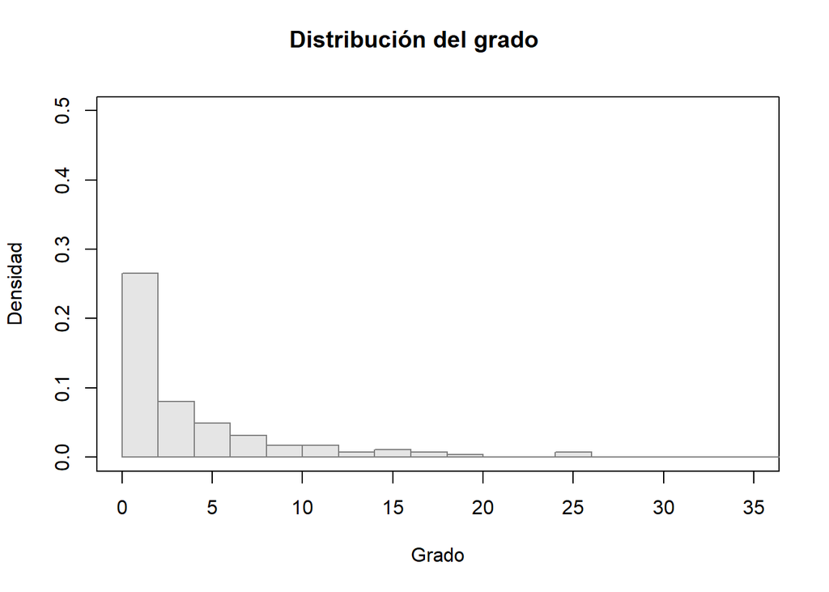

Figure 3.1: Distribución del grado de la red

```r
# histograma
plot(x = NA,
     y = NA,
     type = "n",
     xlim = c(0,35),
     ylim = c(0,0.5),
     xlab = "Grado",
     ylab = "Densidad",
     main = "")
hist(d, freq = F, col = "gray90", border = "gray50", add = T, breaks = 25)
title(main = "Distribución del grado", outer = T, line = -2)
```

Se observa una distribución de grados sesgada a la derecha, lo que indica que la mayoría de los nodos presentan un número reducido de conexiones, mientras que solo unos pocos concentran un número elevado de enlaces. Esto sugiere una estructura heterogénea en la conectividad de la red, donde algunos actores desempeñan un papel más central al mantener un mayor número de relaciones.

### 3.2.2 Distribución de las distancias geodésicas

```r
d <- distances(graph = g)
```

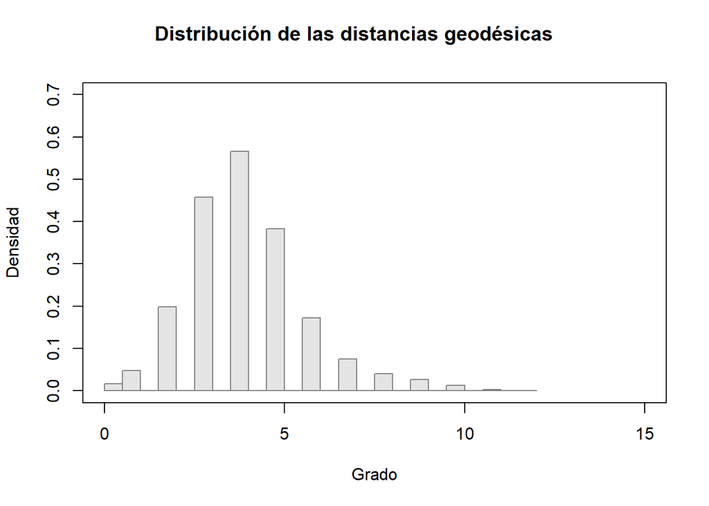

Figure 3.2: Distribución de las distancias geodésicas de la red

```r
# histograma
plot(x = NA,
     y = NA,
     type = "n",
     xlim = c(0,15),
     ylim = c(0,0.7),
     xlab = "Grado",
     ylab = "Densidad",
     main = "")
hist(d, freq = F, col = "gray90", border = "gray50", add = T, breaks = 25)
title(main = "Distribución de las distancias geodésicas", outer = T, line = -2)
```

La distribución de las distancias geodésicas también presenta un sesgo hacia la derecha, aunque menos pronunciado que el observado en la distribución de grados. La mayor concentración de distancias se encuentra alrededor de cuatro pasos, lo que indica que, en promedio, cualquier par de nodos puede conectarse a través de un número relativamente pequeño de intermediarios. Esto sugiere que la red mantiene una buena conectividad entre sus actores.

### 3.2.3 Conectividad

```r
tabla.3bconectividad %>%
  kableExtra::kbl(caption = 'Métricas de conectividad',
                    digits = 3) %>%
  kableExtra::kable_minimal()
```

Table 3.3: Métricas de conectividad

| Medidas | Valores |
| --- | --- |
| ¿Está conectado | FALSE |
| Conectividad nodal | 0 |
| Conectividad por aristas | 0 |
| Puntos de artículación | N2;N14;N77;N75;N109;N99;N23;N18;N56;N52;N36;N61;N47;N68;N27;N11 |

### 3.2.4 Clanes

Para la elaboración del gráfico se tuvo en cuenta la familia a la cual pertenecía o estaba relacionado, mientras que la profesiones y datos faltantes se consideraron como *sin clan*.

```r
V(g)$size <- rescale(
  degree(g),
  to = c(6, 20)
)

clanes <- unique(V(g)$clan)

cols <- setNames(
  rainbow(length(clanes)),
  clanes
)

## opcional: que los no afiliados sean grises
cols["Sin clan"] <- "gray80"

V(g)$color <- cols[V(g)$clan]

set.seed(1101)

lay <- layout_with_fr(g)
```

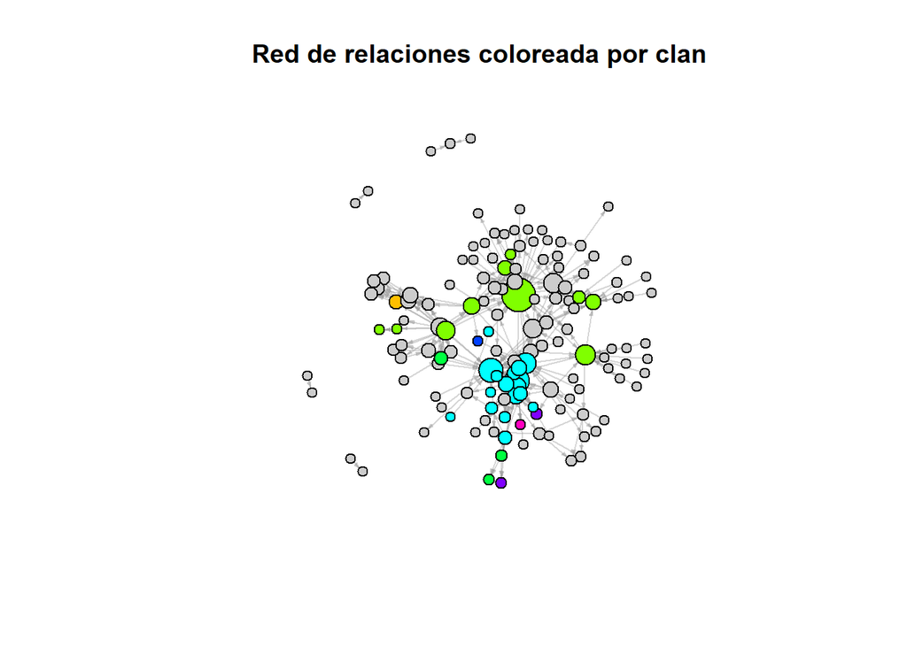

Figure 3.3: Red de relaciones coloreada por clan

```r
plot(
  g,
  layout = lay,
  vertex.size = V(g)$size,
  vertex.color = V(g)$color,
  vertex.label = NA,
  edge.color = adjustcolor("gray60", alpha.f = 0.4),
  edge.arrow.size = 0.2,
  main = "Red de relaciones coloreada por clan"
)
```

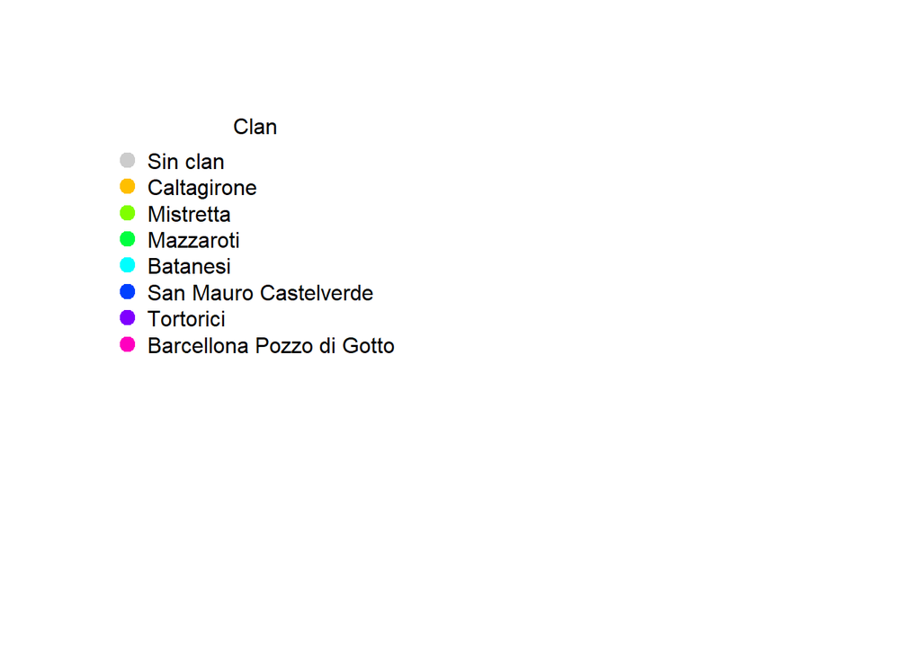

Figure 3.4: Red de relaciones coloreada por clan

```r
plot.new()

legend(
  "topleft",
  legend = names(cols),
  col = cols,
  pch = 19,
  pt.cex = 1.5,
  bty = "n",
  title = "Clan"
)
```

Se observa que los integrantes del clan Batanesi tienden a concentrarse espacialmente en una misma región de la red, lo que sugiere una mayor interacción entre sus miembros. En contraste, los integrantes de los demás clanes aparecen más dispersos y distribuidos a lo largo de la red, sin formar agrupaciones tan claramente definidas.

## 3.3 c. Evaluar la importancia estructural de los nodos mediante grado, fuerza y medidas de centralidad, estudiar la cohesion de la red a través de cliques, densidad y transitividad, y apoyar la interpretacion con visualizaciones adecuadas.

### 3.3.1 Centralidad

```r
medidas_1gcentralidad %>%
  kableExtra::kbl(
    caption = "Resultados",
    digits = 3
  ) %>%
  kableExtra::kable_minimal()
```

Table 3.4: Resultados

| Medidas | Media | Desviacion Estandar |
| --- | --- | --- |
| Grado | 0.032 | 0.040 |
| Cercania | 0.456 | 0.334 |
| Intermediacion | 0.002 | 0.006 |
| Propio | 0.057 | 0.140 |

En promedio, los nodos presentan un grado normalizado bajo (0.032), lo que indica que cada actor mantiene relaciones con una proporción reducida del total de integrantes de la red. Asimismo, la intermediación promedio (0.002) es muy baja, sugiriendo que la mayoría de los actores no desempeña un papel relevante como puente en la comunicación entre otros nodos. En contraste, la cercanía presenta una media de 0.456, aunque con una desviación estándar relativamente alta (0.334), lo que evidencia diferencias importantes en la facilidad con la que los actores pueden alcanzar al resto de la red. Finalmente, la centralidad de vector propio presenta una media baja (0.057) y una desviación estándar superior a la media (0.140), indicando que solo un reducido grupo de actores se encuentra conectado con otros nodos altamente influyentes.

### 3.3.2 Cohesión

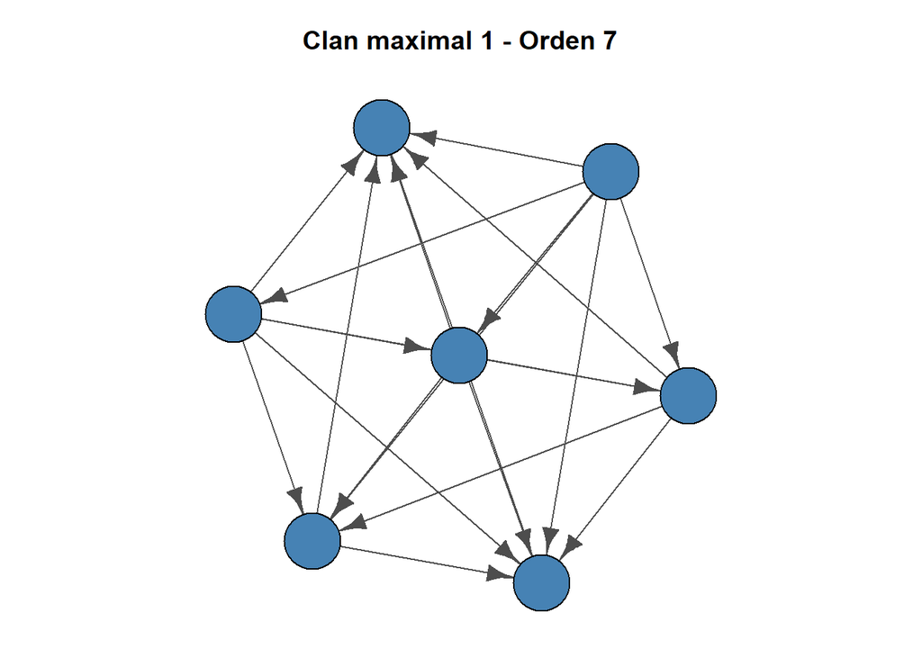

```r
tabla_cliques <- sapply(
  X = seq_len(clique_num(g)),
  FUN = \(k) {
    count_max_cliques(g, min = k, max = k)
  }
)

tabla_cliques <- data.frame(
  clique = seq_along(tabla_cliques),
  frecuencia = tabla_cliques
)

tabla_cliques <- dplyr::filter(
  tabla_cliques,
  frecuencia != 0
)

clanes_maximales <- largest_cliques(g)

par(mfrow = c(1, 1), mar = c(1, 1, 3, 1))

for (k in seq_along(clanes_maximales)) {

  clan_maximal <- induced_subgraph(
    g,
    vids = clanes_maximales[[k]]
  )

  plot(
    clan_maximal,
    main = paste(
      "Clan maximal",
      k,
      "- Orden",
      vcount(clan_maximal)
    ),
    vertex.size = 25,
    vertex.label = "",
    vertex.color = "steelblue",
    vertex.frame.color = "black",
    edge.color = "gray30"
  )
}
```

```r
comp <- components(g)

giant_id <- which(comp$membership == which.max(comp$csize))

g_gc <- induced_subgraph(
  g,
  giant_id
)

densidad2c <- data.frame(
  Red=c("Componente gigante","Red completa"),
  Densidad = c(edge_density(g_gc),edge_density(g))
)
```

```r
tabla_cliques %>%
    kableExtra::kbl(
      caption = "Clanes y su Frecuencia para toda la red",
      digits = 3,
      format = 'html'
    ) %>%
    kableExtra::kable_minimal()
```

Table 3.5: Clanes y su Frecuencia para toda la red

| clique | frecuencia |
| --- | --- |
| 2 | 58 |
| 3 | 31 |
| 4 | 21 |
| 5 | 16 |
| 6 | 5 |
| 7 | 1 |

La distribución de los clanes evidencia que predominan los grupos de menor tamaño. En particular, los clanes de dos integrantes son los más frecuentes (58), seguidos por los de tres (31) y cuatro miembros (21). A medida que aumenta el tamaño del clan, su frecuencia disminuye considerablemente, encontrándose únicamente un clan conformado por siete integrantes. Este comportamiento sugiere que las relaciones altamente cohesivas entre un gran número de actores son poco comunes dentro de la red, predominando en cambio pequeños grupos donde todos sus miembros mantienen vínculos entre sí.

```r
densidad2c %>%
  kableExtra::kbl(
    caption = "Densidad de las componentes gigantes de la red completa",
    digits = 3
  ) %>%
  kableExtra::kable_minimal()
```

Table 3.6: Densidad de las componentes gigantes de la red completa

| Red | Densidad |
| --- | --- |
| Componente gigante | 0.018 |
| Red completa | 0.016 |

La densidad de la componente gigante (0.018) es ligeramente superior a la de la red completa (0.016). Este resultado era esperado, ya que al restringir el análisis a la componente de mayor tamaño se excluyen los nodos aislados y las componentes pequeñas, concentrando las conexiones en un subconjunto de actores más interrelacionados. No obstante, la diferencia entre ambas densidades es reducida, lo que indica que, incluso dentro de la componente gigante, la red mantiene una estructura poco densa.

### 3.3.3 Transitividad

```r
# Transitividad local
tabla_1c_transitividadg <- transitivity(
  graph = g,
  type = "local"
)

tabla_1c_transitividadg[is.nan(tabla_1c_transitividadg)] <- NA

# Transitividad global
trans_global <- transitivity(
  graph = g,
  type = "global"
)

# Datos para el histograma
df <- data.frame(
  transitividad = tabla_1c_transitividadg
)

# Gráfico
grafico_transitividad <-
  ggplot(df, aes(x = transitividad)) +
  geom_histogram(
    col = "gray24",
    fill = "steelblue"
  ) +
  labs(
    title = "Distribución de la transitividad local",
    x = "Transitividad local",
    y = "Frecuencia"
  ) +
  geom_vline(
    aes(
      xintercept = trans_global,
      color = "Global"
    ),
    linewidth = 1.2
  ) +
  annotate(
    "text",
    x = trans_global,
    y = Inf,
    label = round(trans_global, 3),
    vjust = 2,
    color = "black"
  ) +
  scale_color_manual(
    name = "",
    values = c(Global = "gray49")
  ) +
  theme_minimal()
```

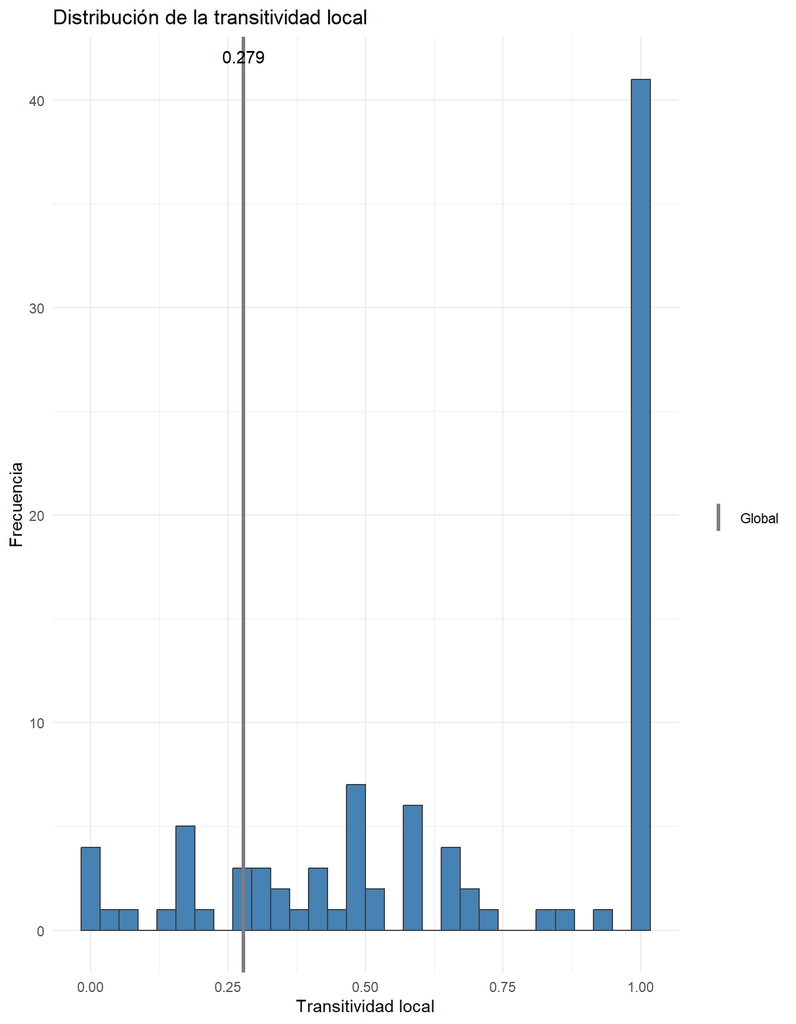

Figure 3.5: Distribución de la transitividad local en la red completa

```r
grafico_transitividad
```

La distribución de la transitividad local presenta una marcada heterogeneidad entre los nodos. Se observa una alta concentración de valores iguales a 1, lo que indica que numerosos actores pertenecen a vecindarios completamente cohesionados, donde todos sus vecinos están conectados entre sí. No obstante, también existen nodos con valores bajos de transitividad local, evidenciando que esta propiedad no es uniforme en toda la red.

## 3.4 d. Aplicar y comparar métodos de deteccion de comunidades, evaluar la modularidad de las particiones, analizar la asortatividad por grado y por clan si corresponde, contrastar las comunidades detectadas con los clanes conocidos y visualizar la particion más adecuada.

Para este inciso se decidió usar la versión no dirigida (*G*) para poder comparar varios métodos de cluster.

```r
tabla_clusters  %>%
  kableExtra::kbl(
    caption = "Modularidad de los algoritmos con respecto a las familias (clanes)",
    digits = 3
  ) %>%
  kableExtra::kable_minimal()
```

Table 3.7: Modularidad de los algoritmos con respecto a las familias (clanes)

|  | Algoritmo | Comunidades | Modularidad |
| --- | --- | --- | --- |
| FastGreedy | FastGreedy | 10 | 0.572 |
| Walktrap | Walktrap | 11 | 0.555 |
| Leiden | Leiden | 109 | 0.316 |
| LabelPropagation | LabelPropagation | 11 | 0.553 |

Los algoritmos FastGreedy, Walktrap y Label Propagation presentan valores de modularidad superiores a 0.55, indicando una estructura comunitaria relativamente bien definida. En particular, FastGreedy obtiene la mayor modularidad (0.572), por lo que proporciona la partición que mejor separa las comunidades de la red. Por el contrario, el algoritmo Leiden identifica un número muy elevado de comunidades (109), lo que se traduce en una menor modularidad (0.316), sugiriendo una sobrefragmentación de la red.

```r
mods <- tabla_clusters$Modularidad

validacion2dclusters <- clusters_coords[[which.max(mods)]]

V(G)$clan <- str_extract(
  V(G)$role,
  "(?<=family '').*?(?='')"
)

V(G)$clan[is.na(V(G)$clan)] <- "Sin clan"
```

```r
table(
  Clan = V(G)$clan,
  Comunidad = membership(validacion2dclusters)
) %>%
  kableExtra::kbl(
    caption = "Frecuencia entre comunidades y familias (clanes)",
    digits = 3
  ) %>%
  kableExtra::kable_minimal()
```

Table 3.8: Frecuencia entre comunidades y familias (clanes)

|  | 1 | 2 | 3 | 4 | 5 | 6 | 7 | 8 | 9 | 10 |
| --- | --- | --- | --- | --- | --- | --- | --- | --- | --- | --- |
| Barcellona Pozzo di Gotto | 0 | 1 | 0 | 0 | 0 | 0 | 0 | 0 | 0 | 0 |
| Batanesi | 1 | 14 | 0 | 0 | 2 | 0 | 0 | 0 | 0 | 0 |
| Caltagirone | 0 | 0 | 1 | 0 | 0 | 0 | 0 | 0 | 0 | 0 |
| Mazzaroti | 0 | 0 | 1 | 0 | 2 | 0 | 0 | 0 | 0 | 0 |
| Mistretta | 3 | 0 | 4 | 2 | 0 | 1 | 0 | 0 | 0 | 0 |
| San Mauro Castelverde | 0 | 0 | 1 | 0 | 0 | 0 | 0 | 0 | 0 | 0 |
| Sin clan | 29 | 19 | 16 | 17 | 2 | 16 | 3 | 2 | 2 | 2 |
| Tortorici | 0 | 1 | 0 | 0 | 1 | 0 | 0 | 0 | 0 | 0 |

La distribución de las familias entre las comunidades evidencia que los clanes identificados no corresponden de manera exacta con la estructura comunitaria de la red. Aunque algunas familias presentan una mayor concentración en una comunidad específica, como ocurre con Batanesi, cuyos integrantes se ubican principalmente en la comunidad 2, otras familias, como Mistretta y Mazzaroti, se encuentran distribuidas entre varias comunidades. Asimismo, los actores sin afiliación a un clan aparecen repartidos en prácticamente todas las comunidades, indicando que la organización estructural de la red no depende exclusivamente de la pertenencia a una familia.

```r
mejor_algoritmo <- tabla_clusters$Algoritmo[
  which.max(tabla_clusters$Modularidad)
]
ord <- order(
  sizes(validacion2dclusters),
  decreasing = TRUE
)[1:min(10, length(sizes(validacion2dclusters)))]
```

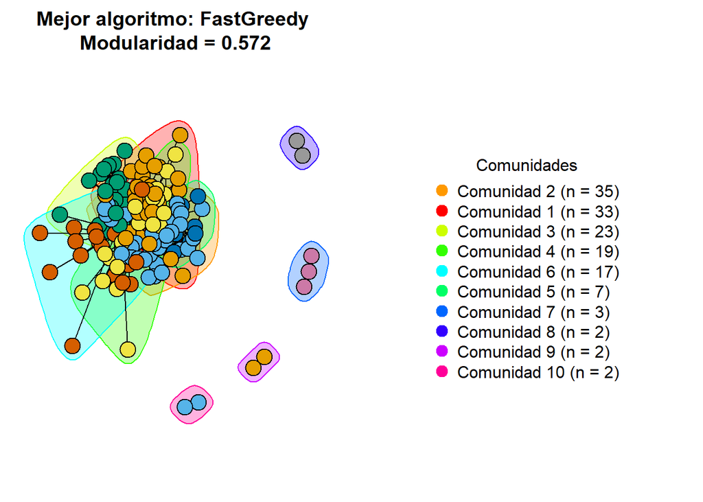

Figure 3.6: Visualización del mejor cluster de acuerdo a modularidad

```r
# Colores usados por igraph
cols <- rainbow(length(sizes(validacion2dclusters)))

par(
  mfrow = c(1, 2),
  mar = c(1, 1, 3, 1)
)

plot(
  validacion2dclusters,
  G,
  layout = layout_kk,
  vertex.size = 12,
  vertex.label = NA,
  main = paste(
    "Mejor algoritmo:",
    mejor_algoritmo,
    "\nModularidad =",
    round(max(tabla_clusters$Modularidad), 3)
  )
)

plot.new()

legend(
  "center",
  legend = paste0(
    "Comunidad ",
    ord,
    " (n = ",
    sizes(validacion2dclusters)[ord],
    ")"
  ),
  col = cols[ord],
  pch = 19,
  pt.cex = 1.5,
  bty = "n",
  title = "Comunidades"
)
```

En conjunto, estos resultados sugieren que las comunidades detectadas por los algoritmos reflejan patrones de interacción más complejos que la simple pertenencia a un clan. Es decir, aunque la afiliación familiar influye en algunos casos, las relaciones de la red también están determinadas por vínculos entre actores de diferentes familias y por individuos sin una afiliación conocida.

## 3.5 e. Ajustar los modelos considerados previamente incorporando la informacion nodal relevante cuando sea pertinente, presentar e interpretar sus resultados mediante tablas y gráficos, evaluar su bondad de ajuste con base en densidad, transitividad, asortatividad y distancia geodésica promedio, y comparar su capacidad predictiva mediante validacion cruzada de 5 particiones. Las secciones de bondad de ajuste y capacidad predictiva deben tener una extension máxima de 1000 palabras cada una.

```r
set.seed(1927)
# Modelo nulo
g_net <- asNetwork(g)
m1 <- ergm(g_net ~ edges)
```

```
## Starting maximum pseudolikelihood estimation (MPLE):
```

```
## Obtaining the responsible dyads.
```

```
## Evaluating the predictor and response matrix.
```

```
## Maximizing the pseudolikelihood.
```

```
## Finished MPLE.
```

```
## Evaluating log-likelihood at the estimate.
```

```r
# Modelo de grafos aleatorios generalizado
in_deg <- degree(
  g,
  mode = "in"
)

out_deg <- degree(
  g,
  mode = "out"
)

m2 <- sample_degseq(
  out.deg = out_deg,
  in.deg = in_deg,
  method = "configuration"
)
#
# ERGM aristas + triangulos
m3 <- ergm(
  g_net ~
    edges +
    triangle,
  estimate = "MPLE"
)
```

```
## Starting maximum pseudolikelihood estimation (MPLE):
## Obtaining the responsible dyads.
## Evaluating the predictor and response matrix.
## Maximizing the pseudolikelihood.
## Finished MPLE.
## Evaluating log-likelihood at the estimate.
```

```r
# ERGM aristas + triangulos + clan
m4 <- ergm(
  g_net ~
    edges +
    triangle +
    nodematch("clan"),
  estimate = "MPLE"
)
```

```
## Starting maximum pseudolikelihood estimation (MPLE):
## Obtaining the responsible dyads.
## Evaluating the predictor and response matrix.
## Maximizing the pseudolikelihood.
## Finished MPLE.
## Evaluating log-likelihood at the estimate.
```

```r
# Bloques estocásticos
A <- as.matrix(as_adjacency_matrix(g))
m5 <- BM_bernoulli(
  "SBM",
  A
)
m5$estimate()
```

```
## -> Estimation for 1 groups
##                 -> 1 initializations provided
##                 -> 0 initializations already used
##             -> Estimation with 1 initializations
##   Non-parallel jobs: 0/1                                        -> Better ICL criterion found
##                     -> new ICL: -1671.16963021199
##                     -> old ICL: NA
```

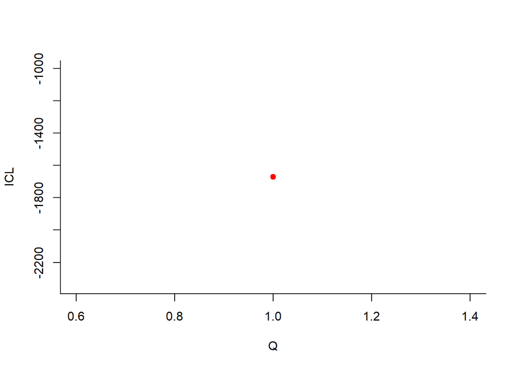

[output not shown]

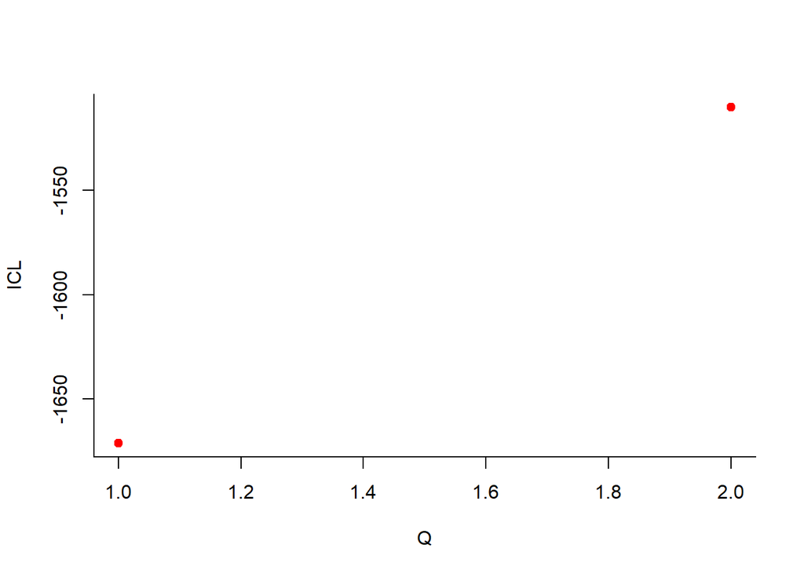

[output not shown]

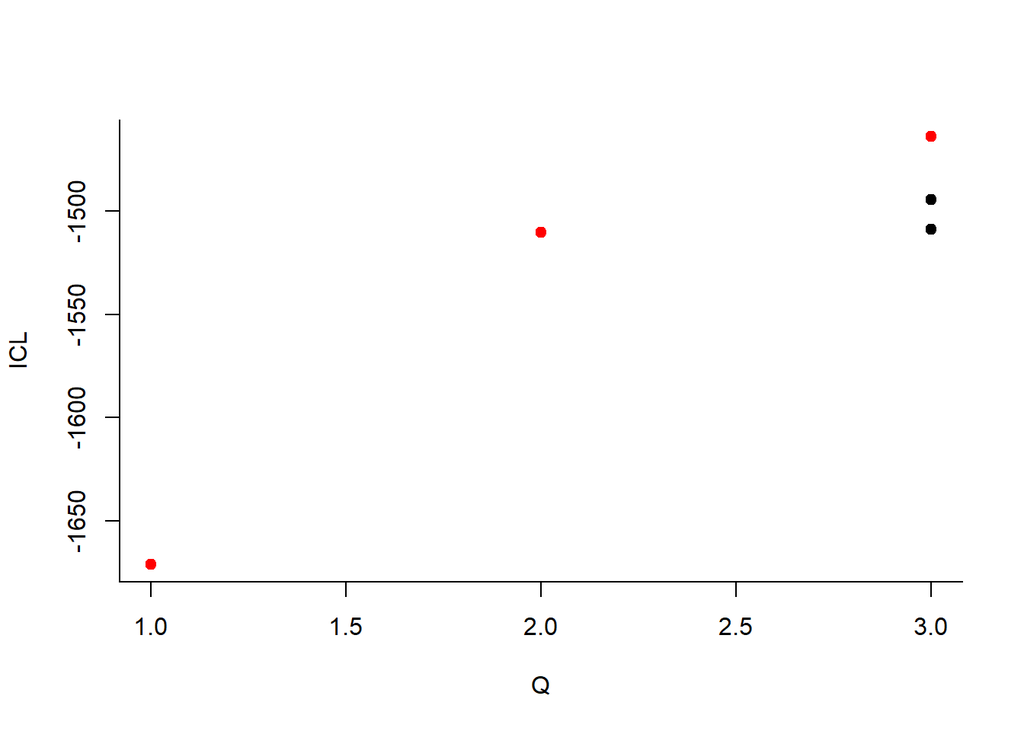

[output not shown]

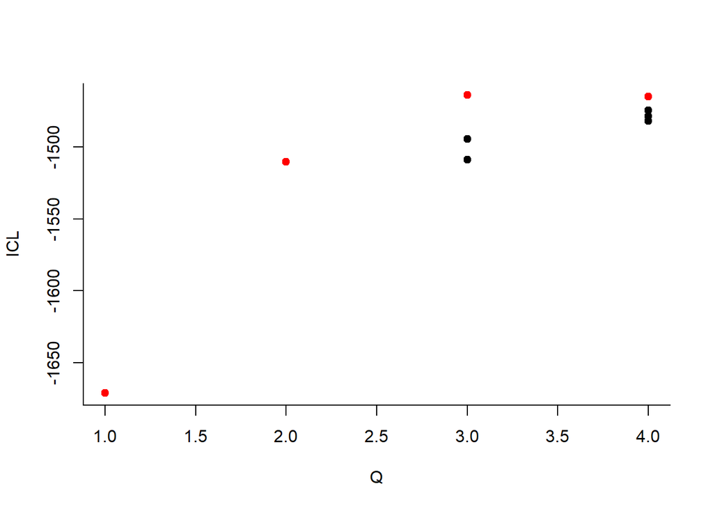

[output not shown]

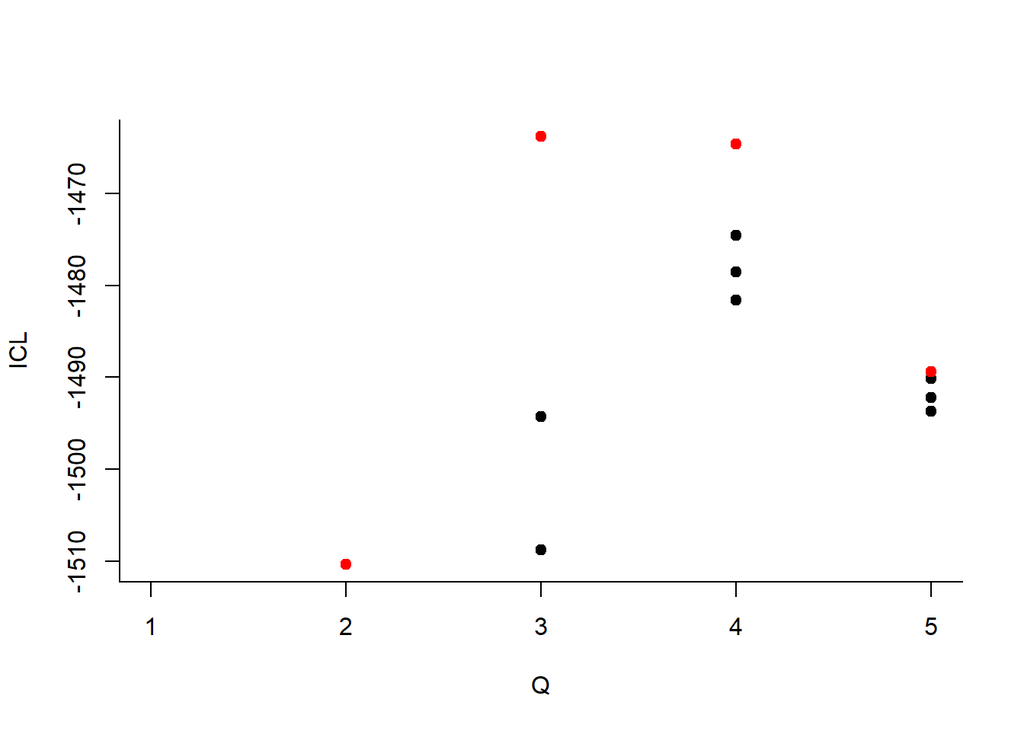

[output not shown]

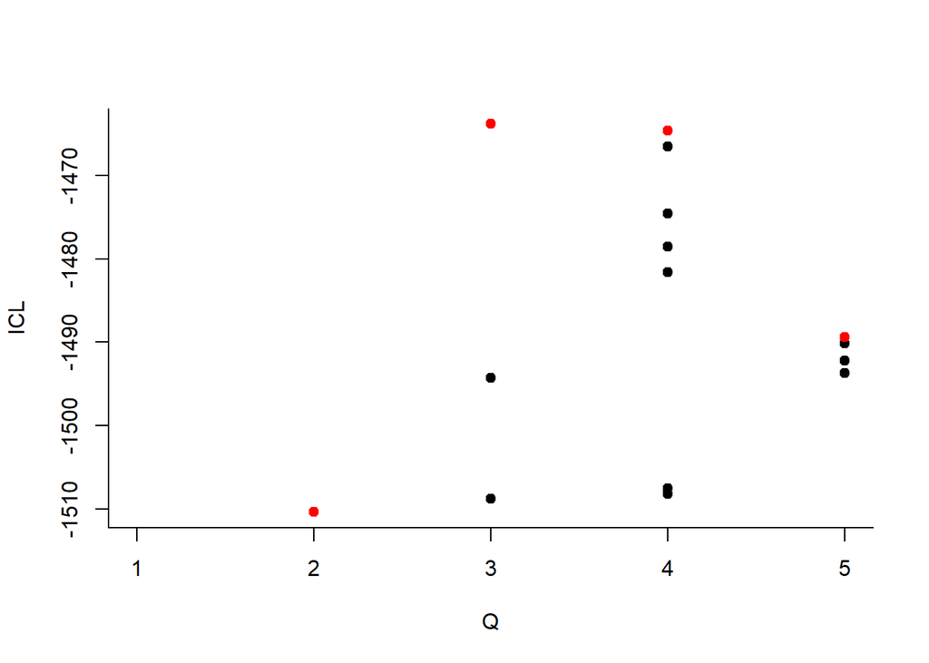

[output not shown]

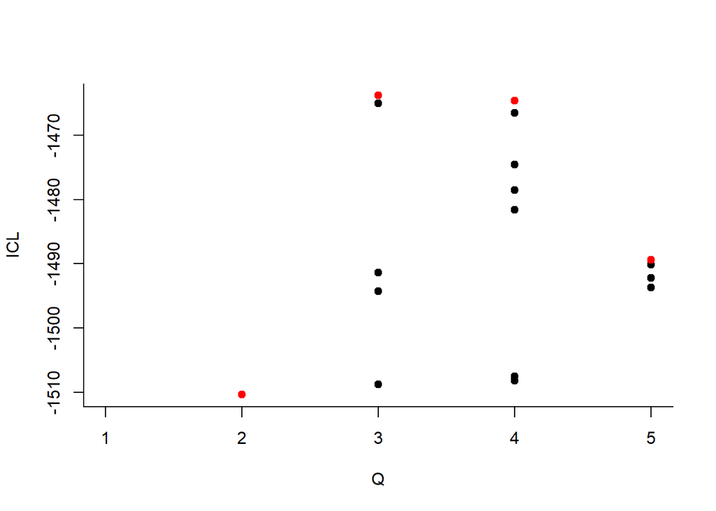

[output not shown]

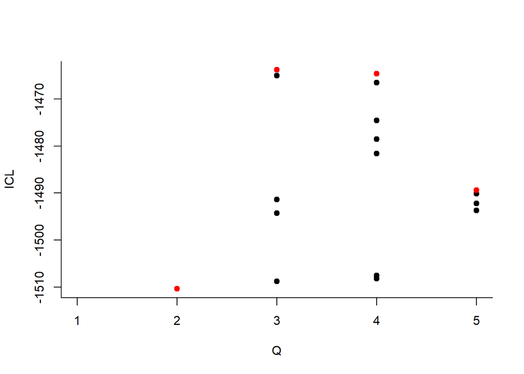

[output not shown]

```r
# Modelo de espacio latente
m6 <- ergmm(
  g_net ~ euclidean(d = 2)
)
# Modelo de sociabilidad
a_sigma <- 2
b_sigma <- 1

a_tau <- 0.01
b_tau <- 0.01

m7 <- gibbs_sampler(
  y = A,
  n_iter = 30000,
  n_burn = 10000,
  n_thin = 20
)
```

```
## Iniciando Gibbs...
## Progreso: 10%
## Progreso: 20%
## Progreso: 30%
## Progreso: 40%
## Progreso: 50%
## Progreso: 60%
## Progreso: 70%
## Progreso: 80%
## Progreso: 90%
## Progreso: 100%
## Finalizado.
```

### 3.5.1 Modelo de grafos aleatorios

```r
tabla_ergm <- summary(m1)$coefficients  %>%
  as.data.frame() %>%
  tibble::rownames_to_column("Parámetro") %>%
  rename(
    "Estimación" = Estimate,
    `Error estándar` = `Std. Error`,
    `Valor z` = `z value`,
    `Valor p` = `Pr(>|z|)`
  ) %>%
  mutate(
    `Valor p` = ifelse(`Valor p` < 0.001,
                       "<0.001",
                       sprintf("%.3f", `Valor p`)),
    across(c(Estimación, `Error estándar`, `Valor z`),
           ~ round(.x, 3))
  )
```

```r
tabla_ergm %>%
  kableExtra::kbl(
    caption = "Resultados del modelo ERGM para la red",
    align = c("l", "c", "c", "c", "c"),
    booktabs = TRUE
  ) %>%
  kableExtra::kable_styling(
    full_width = FALSE,
    bootstrap_options = c("striped", "hover")
  )
```

Table 3.9: Resultados del modelo ERGM para la red

| Parámetro | Estimación | Error estándar | MCMC % | Valor z | Valor p |
| --- | --- | --- | --- | --- | --- |
| edges | -4.119 | 0.056 | 0 | -73.655 | <0.001 |

El modelo nulo indica que la red presenta una baja propensión general a la formación de enlaces, como lo evidencia el coeficiente negativo y estadísticamente significativo del término edges. Esto refleja que, en ausencia de otros efectos, la red es relativamente dispersa y la probabilidad de que exista un vínculo entre dos actores es baja.

### 3.5.2 Modelo de grafos aleatorios generalizado

#### 3.5.2.1 Tabla

```r
tabla_m2 <- data.frame(Medida=c("Nodos",
                                 "Aristas",
                                 "Grado medio",
                                 "Densidad"),
                        Observada=c(vcount(g),
                                    ecount(g),
                                    mean(degree(g)),
                                    edge_density(g)),
                        Simulada=c(vcount(m2),
                                    ecount(m2),
                                    mean(degree(m2)),
                                    edge_density(m2)))
```

```r
tabla_m2 %>%
  kableExtra::kbl(
    caption = "Resultados del modelo de grafos aleatorios generalizado para la red",
    align = c("l", "c", "c", "c", "c"),
    booktabs = TRUE,
    digits = 3
  ) %>%
  kableExtra::kable_styling(
    full_width = FALSE,
    bootstrap_options = c("striped", "hover")
  )
```

Table 3.10: Resultados del modelo de grafos aleatorios generalizado para la red

| Medida | Observada | Simulada |
| --- | --- | --- |
| Nodos | 143.000 | 143.000 |
| Aristas | 325.000 | 325.000 |
| Grado medio | 4.545 | 4.545 |
| Densidad | 0.016 | 0.016 |

#### 3.5.2.2 Visualización

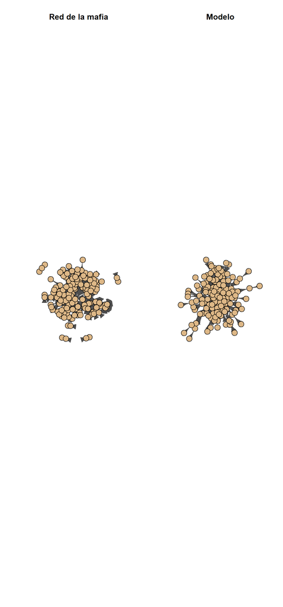

```r
par(mfrow=c(1,2))
plot(g,
       vertex.size = 15,
       vertex.label = "",
       vertex.color       = "burlywood",
       vertex.frame.color = "black",
       edge.color         = "gray30",
       main='Red de la mafia')
plot(m2,
       vertex.size = 15,
       vertex.label = "",
       vertex.color       = "burlywood",
       vertex.frame.color = "black",
       edge.color         = "gray30",
       main='Modelo')
```

#### 3.5.2.3 Discusión

El modelo de configuración preserva la secuencia de grados, pero puede generar lazos y aristas múltiples. En consecuencia, aunque reproduce exactamente medidas como el número de aristas y la densidad, la estructura de la red simulada puede diferir de la observada.

### 3.5.3 Modelo de grafos aleatorios exponencial con número de aristas y triángulos

```r
tabla_ergm <- summary(m3)$coefficients  %>%
  as.data.frame() %>%
  tibble::rownames_to_column("Parámetro") %>%
  rename(
    "Estimación" = Estimate,
    `Error estándar` = `Std. Error`,
    `Valor z` = `z value`,
    `Valor p` = `Pr(>|z|)`
  ) %>%
  mutate(
    `Valor p` = ifelse(`Valor p` < 0.001,
                       "<0.001",
                       sprintf("%.3f", `Valor p`)),
    across(c(Estimación, `Error estándar`, `Valor z`),
           ~ round(.x, 3))
  )
```

```r
tabla_ergm %>%
  kableExtra::kbl(
    caption = "Resultados del modelo ERGM con número de aristas y triángulos para la red de consenso",
    align = c("l", "c", "c", "c", "c"),
    booktabs = TRUE
  ) %>%
  kableExtra::kable_styling(
    full_width = FALSE,
    bootstrap_options = c("striped", "hover")
  )
```

Table 3.11: Resultados del modelo ERGM con número de aristas y triángulos para la red de consenso

| Parámetro | Estimación | Error estándar | MCMC % | Valor z | Valor p |
| --- | --- | --- | --- | --- | --- |
| edges | -5.060 | 0.084 | 0 | -60.117 | <0.001 |
| triangle | 0.919 | 0.031 | 0 | 29.223 | <0.001 |

El coeficiente negativo y significativo del término edges indica que la red presenta una baja propensión general a la formación de enlaces, lo que es consistente con una estructura relativamente dispersa. Sin embargo, el coeficiente positivo y significativo del término triangle evidencia una tendencia al cierre triádico, indicando que, cuando dos actores comparten un vecino en común, aumenta la probabilidad de que también establezcan un vínculo entre sí. En consecuencia, aunque la red no es densa, los enlaces existentes muestran una tendencia a organizarse en triángulos.

### 3.5.4 Modelo de grafos aleatorios exponencial con número de aristas, triángulos y rol

```r
tabla_ergm <- summary(m4)$coefficients  %>%
  as.data.frame() %>%
  tibble::rownames_to_column("Parámetro") %>%
  rename(
    "Estimación" = Estimate,
    `Error estándar` = `Std. Error`,
    `Valor z` = `z value`,
    `Valor p` = `Pr(>|z|)`
  ) %>%
  mutate(
    `Valor p` = ifelse(`Valor p` < 0.001,
                       "<0.001",
                       sprintf("%.3f", `Valor p`)),
    across(c(Estimación, `Error estándar`, `Valor z`),
           ~ round(.x, 3))
  )
```

```r
tabla_ergm %>%
  kableExtra::kbl(
    caption = "Resultados del modelo ERGM con número de aristas, triángulos y rol",
    align = c("l", "c", "c", "c", "c"),
    booktabs = TRUE
  ) %>%
  kableExtra::kable_styling(
    full_width = FALSE,
    bootstrap_options = c("striped", "hover")
  )
```

Table 3.12: Resultados del modelo ERGM con número de aristas, triángulos y rol

| Parámetro | Estimación | Error estándar | MCMC % | Valor z | Valor p |
| --- | --- | --- | --- | --- | --- |
| edges | -4.820 | 0.102 | 0 | -47.310 | <0.001 |
| triangle | 0.914 | 0.031 | 0 | 29.135 | <0.001 |
| nodematch.clan | -0.472 | 0.127 | 0 | -3.708 | <0.001 |

De manera interesante, el término nodematch.clan presenta un coeficiente negativo y estadísticamente significativo. Esto indica que, una vez controlados el número de aristas y la tendencia a formar triángulos, pertenecer al mismo clan disminuye la probabilidad de que dos actores establezcan un enlace directo. En consecuencia, la pertenencia a un mismo clan no parece favorecer las relaciones dentro de la red y, por el contrario, las conexiones tienden a establecerse con actores de otros clanes o sin afiliación conocida.

### 3.5.5 Modelo de bloques estocásticos

#### 3.5.5.1 Tabla

```r
extraer_sbm(modelo = m5) %>%
  dplyr::select(-PL) %>%
  kableExtra::kbl(
    caption = "Resultados del modelo de bloques estocásticos para la red",
    align = c("l", "c", "c", "c", "c"),
    booktabs = TRUE
  ) %>%
  kableExtra::kable_styling(
    full_width = FALSE,
    bootstrap_options = c("striped", "hover")
  )
```

Table 3.13: Resultados del modelo de bloques estocásticos para la red

| k_optimo | tamaños | ICL |
| --- | --- | --- |
| 3 | 108, 17, 18 | -1463.842 |

#### 3.5.5.2 Visualización

```r
which.max(m5$ICL)
```

```
## [1] 3
```

```r
Z <- m5$memberships[[3]]$Z

bloques <- apply(
  Z,
  1,
  which.max
)
red_nda <- as_undirected(
  g,
  mode = "collapse"
)
red_nd <- intergraph::asNetwork(red_nda)
network::set.vertex.attribute(
  red_nd,
  "bloque",
  bloques
)
```

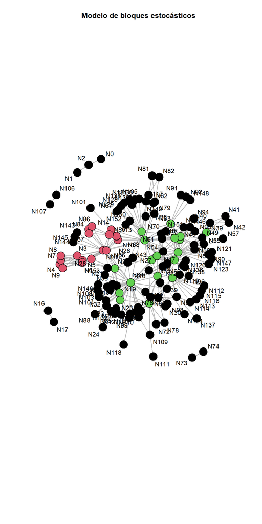

```r
plot(
  red_nd,
  vertex.col = bloques,
  vertex.cex = 2,
  displaylabels = TRUE,
  label = network.vertex.names(red_nd),
  edge.col = "grey70",
  main = "Modelo de bloques estocásticos"
)
```

#### 3.5.5.3 Discusión

El modelo de bloques estocásticos identificó tres comunidades 3.13) como la estructura óptima de la red. No obstante, la distribución de los tamaños evidencia una marcada heterogeneidad, ya que una comunidad concentra la mayor parte de los nodos (108), mientras que las otras dos están conformadas únicamente por 17 y 18 actores, respectivamente. Esto sugiere que la estructura de la red está dominada por un bloque principal acompañado de dos comunidades de menor tamaño.

### 3.5.6 Modelo latente de distancia clásico con dos dimensiones latentes

#### 3.5.6.1 Tabla

```r
tabla_latente <- tibble(
  Característica = c(
    "Modelo",
    "Distribución",
    "Dimensiones latentes",
    "Tamaño de la muestra MCMC",
    "Burn-in",
    "Separación entre muestras"
  ),
  Valor = c(
    "Distancia euclidiana",
    "Bernoulli",
    2,
    m6$control$sample.size,
    m6$control$burnin,
    m6$control$interval
  )
)
```

```r
tabla_latente  %>%
  kbl(
    caption = "Resumen del modelo latente de distancia para la red",
    align = c("l", "c"),
    booktabs = TRUE
  )  %>%
  kable_styling(
    full_width = FALSE,
    bootstrap_options = c("striped", "hover")
  )
```

Table 3.14: Resumen del modelo latente de distancia para la red

| Característica | Valor |
| --- | --- |
| Modelo | Distancia euclidiana |
| Distribución | Bernoulli |
| Dimensiones latentes | 2 |
| Tamaño de la muestra MCMC | 4000 |
| Burn-in | 10000 |
| Separación entre muestras | 10 |

#### 3.5.6.2 Visualización

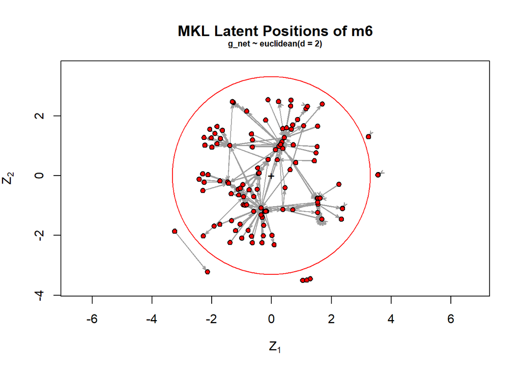

```r
plot(m6)
```

#### 3.5.6.3 Discusión

El modelo latente de distancia representa a los actores en un espacio euclidiano bidimensional, donde la proximidad entre nodos refleja una mayor probabilidad de interacción. Se observa que la mayoría de los actores se concentra alrededor del centro del espacio latente, formando varios grupos relativamente compactos. Esto sugiere la existencia de patrones de interacción locales, en los que los enlaces se establecen preferentemente entre actores cercanos en dicho espacio.

### 3.5.7 Modelo de sociabilidad

```r
tabla_sociabilidad <- tibble(

  Parámetro = c(
    "μ",
    "σ²",
    "τ²"
  ),

  `Media posterior` = c(
    mean(m7$mu),
    mean(m7$sigma2),
    mean(m7$tau2)
  ),

  `Desv. estándar` = c(
    sd(m7$mu),
    sd(m7$sigma2),
    sd(m7$tau2)
  ),

  `IC 2.5%` = c(
    quantile(m7$mu, .025),
    quantile(m7$sigma2, .025),
    quantile(m7$tau2, .025)
  ),

  `IC 97.5%` = c(
    quantile(m7$mu, .975),
    quantile(m7$sigma2, .975),
    quantile(m7$tau2, .975)
  )

)  %>%

  mutate(
    across(
      -Parámetro,
      ~ round(.x, 3)
    )
  )
```

```r
tabla_sociabilidad  %>%

  kbl(
    caption = "Resumen posterior del modelo de sociabilidad",
    align = c("l", "c", "c", "c", "c"),
    booktabs = TRUE
  )  %>%

  kable_styling(
    full_width = FALSE,
    bootstrap_options = c(
      "striped",
      "hover"
    )
  )
```

Table 3.15: Resumen posterior del modelo de sociabilidad

| Parámetro | Media posterior | Desv. estándar | IC 2.5% | IC 97.5% |
| --- | --- | --- | --- | --- |
| μ | -2.432 | 0.104 | -2.640 | -2.219 |
| σ² | 2.781 | 3.745 | 0.627 | 10.612 |
| τ² | 0.286 | 0.058 | 0.195 | 0.415 |

## 3.6 Resumen

Resumen modelos ajustados

[output not shown]

## 3.7 Bondad de ajuste

```r
estadisticas_red <- function(red){

  if (inherits(red, "network")) {
    red <- intergraph::asIgraph(red)
  }

  tibble(
    densidad = edge_density(red),
    transitividad = transitivity(red, type = "global"),
    asortatividad = assortativity_degree(red),
    geodesica = mean_distance(red, directed = TRUE)
  )

}
obs <- estadisticas_red(g)
set.seed(2252)
sim_m1 <- simulate(m1, nsim = 100)
res_m1 <- purrr::map_dfr(
  sim_m1,
  estadisticas_red
)  %>%
  dplyr::mutate(modelo = "M1")
sim_m2 <- replicate(
  100,
  sample_degseq(
    degree(red_nda),
    method = "configuration"
  ),
  simplify = FALSE
)
res_m2 <- purrr::map_dfr(
  sim_m2,
  estadisticas_red
)  %>%
  mutate(modelo = "M2")
sim_m3 <- simulate(m3, nsim = 100)
res_m3 <- purrr::map_dfr(
  sim_m3,
  estadisticas_red
) %>%
  mutate(modelo="M3")

sim_m4 <- simulate(m4, nsim = 100)
res_m4 <- purrr::map_dfr(
  sim_m4,
  estadisticas_red
) %>%
  mutate(modelo="M4")

P <- m5$prediction(2)
diag(P) <- 0
simular_sbm <- function(P){

  A <- matrix(
    rbinom(
      length(P),
      size = 1,
      prob = as.vector(P)
    ),
    nrow = nrow(P),
    byrow = FALSE
  )

  diag(A) <- 0

  ## Asegurar simetría
  A[lower.tri(A)] <- t(A)[lower.tri(A)]

  graph_from_adjacency_matrix(
    A,
    mode = "undirected",
    diag = FALSE
  )

}
sim_m5 <- replicate(
  100,
  simular_sbm(P),
  simplify = FALSE
)
res_m5 <- purrr::map_dfr(
  sim_m5,
  estadisticas_red
)  %>%
  mutate(
    modelo = "M5"
  )

sim_m6 <- replicate(
  100,
  simulate(m6),
  simplify = FALSE
)
res_m6 <- purrr::map_dfr(
  sim_m6,
  estadisticas_red
)  %>%
  mutate(modelo="M6")

simular_sociabilidad <- function(mu, delta){

  n <- length(delta)

  A <- matrix(0, n, n)

  for(i in 1:(n-1)){

    for(j in (i+1):n){

      p <- pnorm(
        mu +
        delta[i] +
        delta[j]
      )

      A[i,j] <- rbinom(
        1,
        size = 1,
        prob = p
      )

      A[j,i] <- A[i,j]

    }

  }

  graph_from_adjacency_matrix(
    A,
    mode = "undirected",
    diag = FALSE
  )

}

idx <- sample(
  seq_along(m7$mu),
  100
)

sim_m7 <- purrr::map(
  idx,
  \(k){

    simular_sociabilidad(
      mu = m7$mu[k],
      delta = m7$delta[k, ]
    )

  }
)
res_m7 <- purrr::map_dfr(
  sim_m7,
  estadisticas_red
)  %>%
  mutate(
    modelo = "M7"
  )

todos <- bind_rows(
  res_m1,
  res_m2,
  res_m3,
  res_m4,
  res_m5,
  res_m6,
  res_m7
)
```

### 3.7.1 Densidad

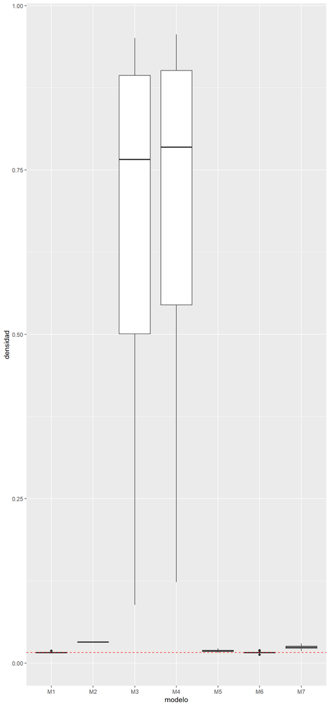

```r
ggplot(
  todos,
  aes(
    x = modelo,
    y = densidad
  )
)+
geom_boxplot()+
geom_hline(
  yintercept = obs$densidad,
  colour="red",
  linetype=2
)
```

### 3.7.2 Transitividad

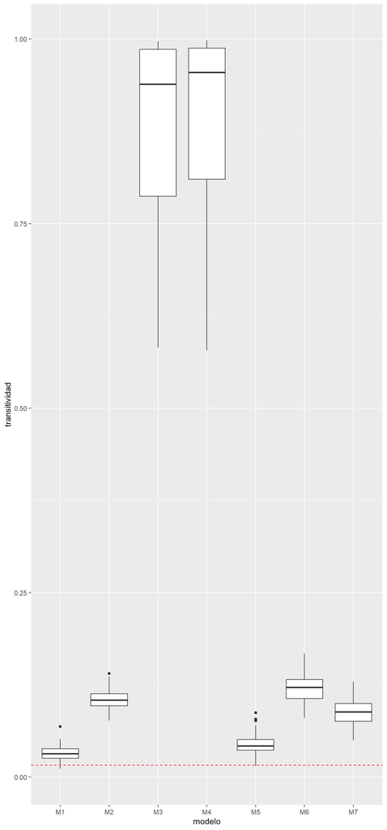

```r
ggplot(
  todos,
  aes(
    x = modelo,
    y = transitividad
  )
)+
geom_boxplot()+
geom_hline(
  yintercept = obs$densidad,
  colour="red",
  linetype=2
)
```

### 3.7.3 Asortatividad

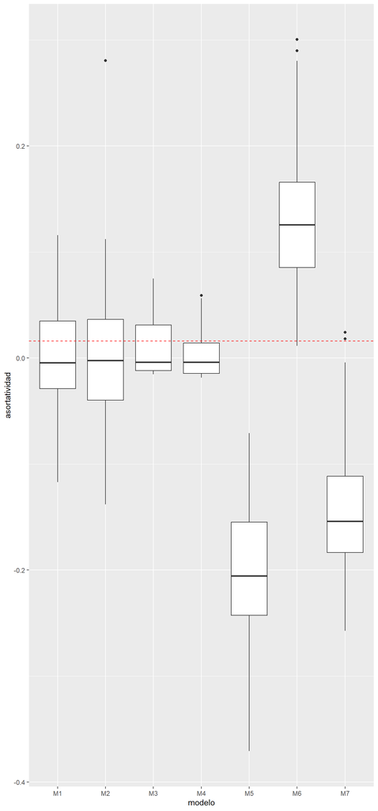

```r
ggplot(
  todos,
  aes(
    x = modelo,
    y = asortatividad
  )
)+
geom_boxplot()+
geom_hline(
  yintercept = obs$densidad,
  colour="red",
  linetype=2
)
```

- Los modelo SBM (M5) y sociabilidad (M7) tienden a subestimar la asortatividad, generando redes con una estructura más desasortativa que la observada.
- El modelo latente (M6) sobreestima la asortatividad, generando una asociación entre nodos similares mayor que la presente en la red observada.

### 3.7.4 Distancia geodésica

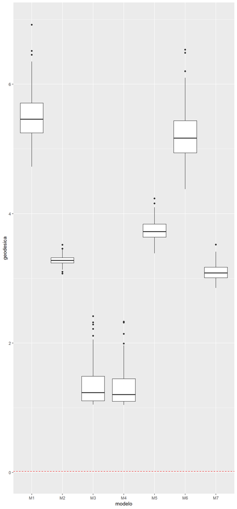

```r
ggplot(
  todos,
  aes(
    x = modelo,
    y = geodesica
  )
)+
geom_boxplot()+
geom_hline(
  yintercept = obs$densidad,
  colour="red",
  linetype=2
)
```

- Los modelos ERGM generan caminos promedio muy cortos debido a la elevada densidad de las redes simuladas.

En conjunto, los diagnósticos muestran que ningún modelo reproduce simultáneamente todas las propiedades estructurales de la red. Los modelos ERGM (M3 y M4) capturan adecuadamente la formación de triángulos según su especificación, pero generan redes excesivamente densas y altamente transitivas, alejándose de la estructura observada. Por su parte, los modelos Bernoulli, de grados, SBM, latente y de sociabilidad reproducen mejor la baja densidad de la red, aunque presentan diferencias en propiedades como la asortatividad y la longitud de los caminos geodésicos. En consecuencia, la elección del modelo depende de cuál característica estructural de la red se considere prioritaria para el análisis.

## 3.8 Validación cruzada

### 3.8.1 Tabla de resumen

```r
cv_total <- bind_rows(
  cv_m1 %>%  mutate(Modelo = "M1: Bernoulli"),
  cv_m2 %>%  mutate(Modelo = "M2: Grados"),
  cv_m3 %>%  mutate(Modelo = "M3: ERGM"),
  cv_m4 %>%  mutate(Modelo = "M4: ERGM + rol"),
  cv_m5 %>%  mutate(Modelo = "M5: SBM"),
  cv_m6 %>%  mutate(Modelo = "M6: Latente"),
  cv_m7 %>%  mutate(Modelo = "M7: Sociabilidad")
)

tabla_cv <-
  cv_total %>%
  group_by(Modelo) %>%
  summarise(
    AUC_media = mean(AUC),
    AUC_sd = sd(AUC),
    Accuracy_media = mean(Accuracy),
    Accuracy_sd = sd(Accuracy),
    .groups = "drop"
  ) %>%
  mutate(
    across(
      -Modelo,
      ~round(.x, 3)
    )
  )
```

```r
tabla_cv %>%
  kableExtra::kbl(caption = "Resultados de la validación cruzada de cinco folds",
    booktabs = TRUE,
    align = c("l","c","c","c","c"),
    col.names = c(
      "Modelo",
      "AUC media",
      "DE",
      "Accuracy media",
      "DE"
    )) %>%
  kableExtra::kable_styling(
    full_width = FALSE,
    position = "center"
  ) %>%
  kableExtra::row_spec(0, bold = T) %>%
  kableExtra::row_spec(
    c(7),
    bold = TRUE,
    background = "#CF2F40",
    color = "white"
  )
```

Table 3.16: Resultados de la validación cruzada de cinco folds

| Modelo | AUC media | DE | Accuracy media | DE |
| --- | --- | --- | --- | --- |
| M1: Bernoulli | 0.500 | 0.000 | 0.976 | 0.004 |
| M2: Grados | 0.730 | 0.048 | 0.968 | 0.006 |
| M3: ERGM | 0.683 | 0.047 | 0.976 | 0.004 |
| M4: ERGM + rol | 0.683 | 0.047 | 0.976 | 0.004 |
| M5: SBM | 0.773 | 0.075 | 0.976 | 0.004 |
| M6: Latente | 0.827 | 0.046 | 0.976 | 0.004 |
| M7: Sociabilidad | 0.835 | 0.046 | 0.976 | 0.004 |

### 3.8.2 Boxplot del AUC

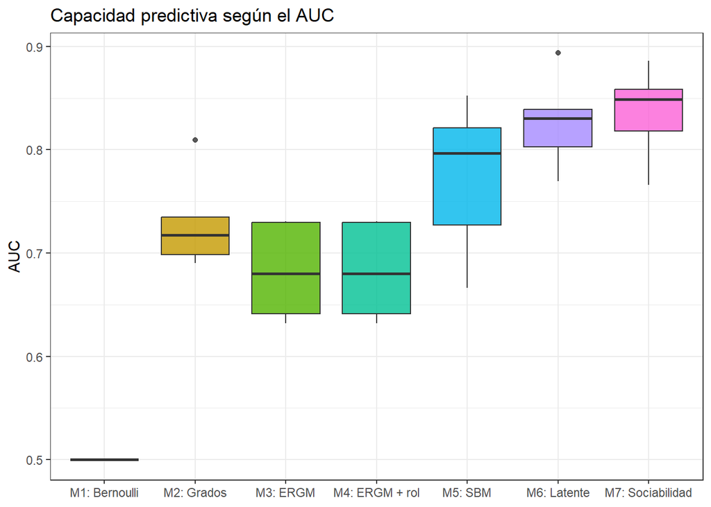

Figure 3.7: Boxplot del área bajo la curva (AUC por sus siglas en inglés)

```r
ggplot(
  cv_total,
  aes(
    Modelo,
    AUC,
    fill = Modelo
  )
) +
  geom_boxplot(
    alpha = .8
  ) +
  labs(
    x = NULL,
    y = "AUC",
    title = "Capacidad predictiva según el AUC"
  ) +
  theme_bw() +
  theme(
    legend.position = "none"
  )
```